# MV130 Trial - Complete Study Report v1.4

Author

Marc Henrion, Eva Kudowa

Published

July 15, 2026

This report is structured in sections mirroring those from the MV130 statistical analysis plan (SAP).

# 1 Full study title

The Influence of MV130 immunotherapy on Nasal Colonisation in a Controlled Human Infection Model of Pneumococcal Carriage in Malawi.

# 2 Short title

MV130 and Pneumococcal Colonisation in Malawi.

# 3 Version History

```r
dfVersion<-data.frame(matrix(ncol=3,nrow=0, dimnames=list(NULL, c("Version", "Date", "Description"))))
dfVersion[nrow(dfVersion)+1,]<-c("v0.1","2025-06-18","First draft of the CSR, drawing large sections from the SAP written by E Kudowa, M Henrion, J Ndaferankhande and S Gordon.")
dfVersion[nrow(dfVersion)+1,]<-c("v0.2","2025-07-02","Adding compliance stratified analysis.")
dfVersion[nrow(dfVersion)+1,]<-c("v0.3","2025-07-15","Adding most other analyses and using the full cleaned and locked NTR data.")
dfVersion[nrow(dfVersion)+1,]<-c("v0.4","2025-07-28","Near-final version, but with several hard-coded data edits for the CONSORT diagram; only non-implemented pre-specified analyses are those where data are not yet ready (NTR at days 44, 49; IgG, IgA).")
dfVersion[nrow(dfVersion)+1,]<-c("v1.0","2025-07-29","First full CSR with validated participant numbers. Still includes several hard-coded data edits for the CONSORT diagram; only non-implemented pre-specified analyses are those where data are not yet ready (NTR at days 44, 49; IgG, IgA).")
dfVersion[nrow(dfVersion)+1,]<-c("v1.1","2025-10-24","Minor correction - wrong counts in Table 5 due to printing of results for MV130, Placebo in wrong order.")
dfVersion[nrow(dfVersion)+1,]<-c("v1.2","2026-06-04","Additional supplementary figures for neutrophil and T-cell proportions over time as requested by a reviewer; NTR data revised after data entry issues were identified - NTR data stamp is now 2026-06-04; NTR by carriage status across study visits now extended up to Day 49 visit as those data have become available; full AI audit of code revealed a few code bugs - almost all were very minor but this identified a column swap in the participant characteristic table; clarification on the analysis population added. The NTR data revision will have affected the primary analysis.")
dfVersion[nrow(dfVersion)+1,]<-c("v1.3","2026-06-10","Adding day 44 and 49 to the primary analysis NTR graph (primary analysis still limited to D14, just adding two more days to the graph). Added post-hoc analyses comparing baseline NTR data to NTR data from the other visits within each study arm. Changed some spelling from American to British English. Added sample sizes of complete data on the NTR (and similar) figures. Added a sex-stratified primary analyses as requested by a reviewer.")
dfVersion[nrow(dfVersion)+1,]<-c("v1.4","2026-07-15","Changed the compliance comparison analysis test from t-test to Wilcoxon test. Added stratified (compliant group only) version of the primary NTR and secondary carriage analyses in response to reviewer request.")

dfVersion[nrow(dfVersion):1,] %>%
  kable(row.names = FALSE) %>%
  kable_styling(full_width = FALSE)
```

Table 1: Version history listing major changes for each new version.

| Version | Date | Description |
| --- | --- | --- |
| v1.4 | 2026-07-15 | Changed the compliance comparison analysis test from t-test to Wilcoxon test. Added stratified (compliant group only) version of the primary NTR and secondary carriage analyses in response to reviewer… |
| v1.3 | 2026-06-10 | Adding day 44 and 49 to the primary analysis NTR graph (primary analysis still limited to D14, just adding two more days to the graph). Added post-hoc analyses comparing baseline NTR data to NTR data … |
| v1.2 | 2026-06-04 | Additional supplementary figures for neutrophil and T-cell proportions over time as requested by a reviewer; NTR data revised after data entry issues were identified - NTR data stamp is now 2026-06-04… |
| v1.1 | 2025-10-24 | Minor correction - wrong counts in Table 5 due to printing of results for MV130, Placebo in wrong order. |
| v1.0 | 2025-07-29 | First full CSR with validated participant numbers. Still includes several hard-coded data edits for the CONSORT diagram; only non-implemented pre-specified analyses are those where data are not yet re… |
| v0.4 | 2025-07-28 | Near-final version, but with several hard-coded data edits for the CONSORT diagram; only non-implemented pre-specified analyses are those where data are not yet ready (NTR at days 44, 49; IgG, IgA). |
| v0.3 | 2025-07-15 | Adding most other analyses and using the full cleaned and locked NTR data. |
| v0.2 | 2025-07-02 | Adding compliance stratified analysis. |
| v0.1 | 2025-06-18 | First draft of the CSR, drawing large sections from the SAP written by E Kudowa, M Henrion, J Ndaferankhande and S Gordon. |

# 4 Deviations from SAP v1.0

The table below lists all deviations from the published MV130 SAP v1.0.

```r
dfDev<-data.frame(matrix(ncol=2,nrow=0, dimnames=list(NULL, c("Date", "Deviation"))))

dfDev<-rbind(dfDev,
             c("2025-07-21","The adjusted model for log(NTR at day 14) now includes log(NTR at day 0) as a predictor. This is not really a deviation, as the SAP did plan to log transform NTR if skew, however was not explicit to also do this for NTR at day 0 as a predictor."),
             c("2025-07-23","Use of the R package logbin for fitting the log-biomial model for the adjusted analysis of experimental carriage; the SAP used the standard glm() function. This is just a technicality as the model is otherwise exactly the same as per SAP."),
             c("2025-07-28","The visual summary of carriage density omits further splitting natural carriage into vaccine type or non-vaccine type and as there was no carriage data collected at D35, D21 is included instead. These are very minor deviations, mostly due to either sparsity (few carriers once stratified by serotype, study arm and visit) or lack (no D35 carriage data) of data."),
             c("2026-06-08","A clarification to the ITT population in the SAP: as per SAP we analysed participant according to the study arm they were randomised to. However, we also required participants to have completed all study follow-up visits. We realise the SAP wording may have been unclear."))

colnames(dfDev)<-c("Date", "Deviation")

dfDev %>%
  kable(row.names = FALSE) %>%
  kable_styling(full_width = FALSE)
```

Table 2: Deviations from the MV130 SAP v1.0.

| Date | Deviation |
| --- | --- |
| 2025-07-21 | The adjusted model for log(NTR at day 14) now includes log(NTR at day 0) as a predictor. This is not really a deviation, as the SAP did plan to log transform NTR if skew, however was not explicit to a… |
| 2025-07-23 | Use of the R package logbin for fitting the log-biomial model for the adjusted analysis of experimental carriage; the SAP used the standard glm() function. This is just a technicality as the model is … |
| 2025-07-28 | The visual summary of carriage density omits further splitting natural carriage into vaccine type or non-vaccine type and as there was no carriage data collected at D35, D21 is included instead. These… |
| 2026-06-08 | A clarification to the ITT population in the SAP: as per SAP we analysed participant according to the study arm they were randomised to. However, we also required participants to have completed all st… |

# 5 List of abbreviations

Table 3 lists all abbreviations used throughout this document.

Table 3: List of abbreviations

| Abbreviation | Explanation |
| --- | --- |
| AE | Adverse event |
| AR | Adverse reaction |
| ATP | According-to-protocol |
| CHIM | Controlled human infection model |
| CI | Confidence interval |
| CSR | Complete study report |
| DMP | Data management plan |
| eCRF | Electronic Case report form |
| FCS | Fully conditional specification |
| IDA | Initial data analysis |
| IgA | Immunoglobulin A |
| IgG | Immunoglobulin G |
| IMP | Investigational medicinal product |
| IQR | Interquartile range |
| ITT | Intention-to-treat |
| LSTM | Liverpool School of Tropical Medicine |
| LTFU | Loss to follow-up |
| MARVELS | Malawi Accelerated Research in Vaccines, Experimental and Laboratory Systems |
| MICE | Multiple imputation using chained equations |
| MLW | Malawi Liverpool Wellcome Research Programme |
| NTR | Neutrophil to T-cell ratio |
| P25 | 25th percentile value |
| P75 | 75th percentile value |
| PCV | Pneumococcal conjugate vaccine |
| PCV-13 | 13-valent pneumococcal conjugate vaccine |
| PI | Post-inoculation |
| PPA | Per-protocol analysis |
| SAE | Serious adverse event |
| SAP | Statistical analysis plan |
| SAR | Serious adverse reaction |
| SD | Standard deviation |
| SUSAR | Suspected unexpected serious adverse reaction |

# 6 Protocol version

# 7 Protocol summary

*Streptococcus pneumoniae* poses a significant global health threat, leading to substantial morbidity and mortality, especially in the developing world. Despite the introduction of Pneumococcal Conjugate Vaccines (PCV), with a 13-valent vaccine (PCV-13) being used in Malawi, challenges persist, including high production costs, limited serotype coverage, and concerns about serotype replacement. In response, for accelerated vaccine evaluations and immunological investigations, a Controlled Human Infection Model (CHIM) was established at the Liverpool School of Tropical Medicine (LSTM) and later transferred to Malawi with the MARVELS programme at Malawi Liverpool Wellcome Research Programme (MLW), demonstrating safety and reproducibility (Collins et al. 2015),(Morton et al. 2021),(Dula et al. 2023). While PCVs have made strides, the limitations necessitate exploration of alternative solutions. MV130, a sublingual preparation comprising heat-inactivated bacterial strains, with *Streptococcus pneumoniae* 60%, *Staphylococcus epidermidis* 15%, *Staphylococcus aureus* 15%, *Klebsiella pneumoniae* 4%, *Moraxella catarrhalis* 3%, *Haemophilus influenzae* 3% as active ingredients, emerges as a promising option. Clinical trials have shown MV130’s efficacy in reducing both viral and bacterial infections, inducing long-lasting immunity, and demonstrating a favourable safety profile. Malawi, despite PCV-13 vaccination efforts, continues to grapple with persistent pneumococcal disease, emphasising the need for innovative approaches like MV130. Building on the success of the CHIM in Malawi, with a recent controlled human infection trial with PCV-13 demonstrating safety (Dula et al. 2023), laying the groundwork for the evaluation of MV130’s efficacy. The robustness of clinical and laboratory procedures, along with positive participant feedback (Kapumba et al. 2020), supports the feasibility of MV130 trials. The Malawian context is characterised by a persistent burden of pneumococcal disease, as evidenced by surveillance data revealing continued nasal carriage of vaccine-type and non-vaccine-type Streptococcus pneumoniae (Swarthout et al. 2020). To address these challenges, the study aims to investigate local and systemic innate and cellular responses to MV130 compared to a placebo. Additionally, the research will explore the modulation of the immune response by experimental pneumococcal carriage, shedding light on the potential of MV130 to prevent nasal colonization and subsequent infections.

# 8 Study design

The MARVELS MV130 study is a double-blinded randomised controlled trial of MV130 versus placebo in adult healthy human participants experimentally subsequently exposed to 160,000 CFU/naris of Streptococcus pneumoniae in the nasopharynx. The investigational medicinal product (IMP) will be MV130 (prepared by Immunotek, S.L.) and a placebo containing none of the active ingredients, only the excipients will also be prepared by the IMP manufacturer. Participants (n=106) will be randomised 1:1 to the two study arms (i.e. 53 per arm). We will closely monitor study participants to ensure safety and tolerability of study procedures. We will measure immune protective responses to *Streptococcus pneumoniae* challenge using mucosal (nasal, throat and saliva) and blood samples. This study is based on the foundation of our NHSRC approved feasibility study protocol (19/08/2246) and the PCV-13 and pneumococcal carriage study protocol 16/07/2519 and will utilise standard operating procedures successfully validated in Malawi. We will indicate throughout this protocol where established feasibility [Established, E] study procedures from the feasibility study / PCV-13 protocols are used and where there are new measures [New, N] for this trial.

The study will be carried out in seven stages:

1. Screening and recruitment: Potential participants will be screened to ensure health and safety as detailed in the methods section [E].
2. Randomization and treatment: Participants will be randomly allocated to administration with MV130 or placebo[N] in randomised blocks (1:1 randomisation MV130 vs. Placebo) participants will receive either MV130 or placebo. MV130 or placebo are administered as 2 sublingual sprays (0.1ml each) in a single procedure once daily for 42 days.
3. Pre IMP administration samples: Samples will be taken before MV130 treatment begins to confirm nasal pneumococcal carriage status and measure immune response [E].
4. Post IMP administration samples : Samples will be taken to measure immune response to MV130/placebo and confirm natural nasal pneumococcal carriage status [E].
5. Inoculation: All participants will be inoculated with Streptococcus pneumoniae serotype 6B to the inside of each naris. We will inoculate at a dose of 160,000 colony forming units per naris [E].
6. Detection of pneumococcal carriage: Nasal wash samples will be taken, according to a standardised protocol, at days 2 and 7 post inoculation(23). Classical microbiological culture will determine experimental nasal colonization with pneumococcal serotype 6B at each time point [E].
7. Immunology response measurements: Blood, mucosal and nasal cell samples will be taken to determine the immunological response to nasal challenge [E].

## 8.1 Study Endpoints

**Primary endpoint**:

- Mucosal neutrophil to T cell ratio (NTR) after 14 days of MV130 treatment.

**Secondary endpoints**:

- Mucosal neutrophil to T cell ratio (NTR) after 35 days of MV130 treatment.
- Experimental pneumococcal serotype 6B carriage density compared between treatments (MV130) and controls (placebo).

## 8.2 Sample size

As of protocol v2.0, the total sample size for MARVELS MV-130 is n=106 participants, 53 per arm.

**Assumptions and sample size estimation for primary objective**

The primary efficacy analysis will compare log (NTR) between MV130 randomised individuals and controls at day 14 post-MV130 treatment using a standard two-sample t-test. A secondary analysis will be adjusted for individual participant characteristics that could impact the endpoint and which may be imbalanced between treatment arms. To inform our sample size calculations, we investigated the distribution of NTR and log (NTR) measurements observed in the MARVELS PCV-13 trial, in the CFU160,000 dose group (Dula et al. 2023).

From the MARVELS PCV-13 trial, there are no major distributional differences between study visits and vaccination groups. The overall standard deviation for log(NTR) is estimated as σ =1.2. The following assumptions have been made with regards to the calculation:

- We assume a standard statistical significance level of 5%.
- We aim for a minimum power of 80%.
- We assume independent data observations.
- We assume that the log(NTR) measurements are not characterised by severe non-normality so that we can assume the sample means to be approximately normally distributed (guaranteed by the Central Limit Theorem unless severe non-normality, such as extreme outliers, is present in the data).
- We assume a standard deviation of σ =1.21 for log(NTR) common to both treatment groups. This is the estimate we observed in the MARVELS PCV-13 trial data.
- Total sample size is limited to 50 in each group assuming a 1:1 randomisation ratio.
- We assume that 6% of sample will not be able to be processed (for a variety of participant and lab technical reasons), meaning that we would recruit 106 participants to have useable data on 100 participants.

Calculations

```r
power.t.test(n=50,sd=1.21,sig.level=0.05,power=0.8,alternative="two.sided")
```

```
     Two-sample t test power calculation

              n = 50
          delta = 0.6847191
             sd = 1.21
      sig.level = 0.05
          power = 0.8
    alternative = two.sided

NOTE: n is number in *each* group
```

With the above assumptions, the study will be able to detect a difference in log(NTR) between both groups of 0.69 with 80% power. This corresponds to a standardised effect size of 0.57 which is typically regarded as a moderate effect size. With the caveat that the average of a log is not the log of an average (meaning the calculation that follows is not correct and should only be viewed as a very rough guide), this corresponds to a relative change in NTR of 98.32% (i.e. slightly less than a doubling).

**Power graphs**

To visualise the sensitivity of the study power on sample size (assuming the same effect size as above), we produce the graph below based on the above parameters.

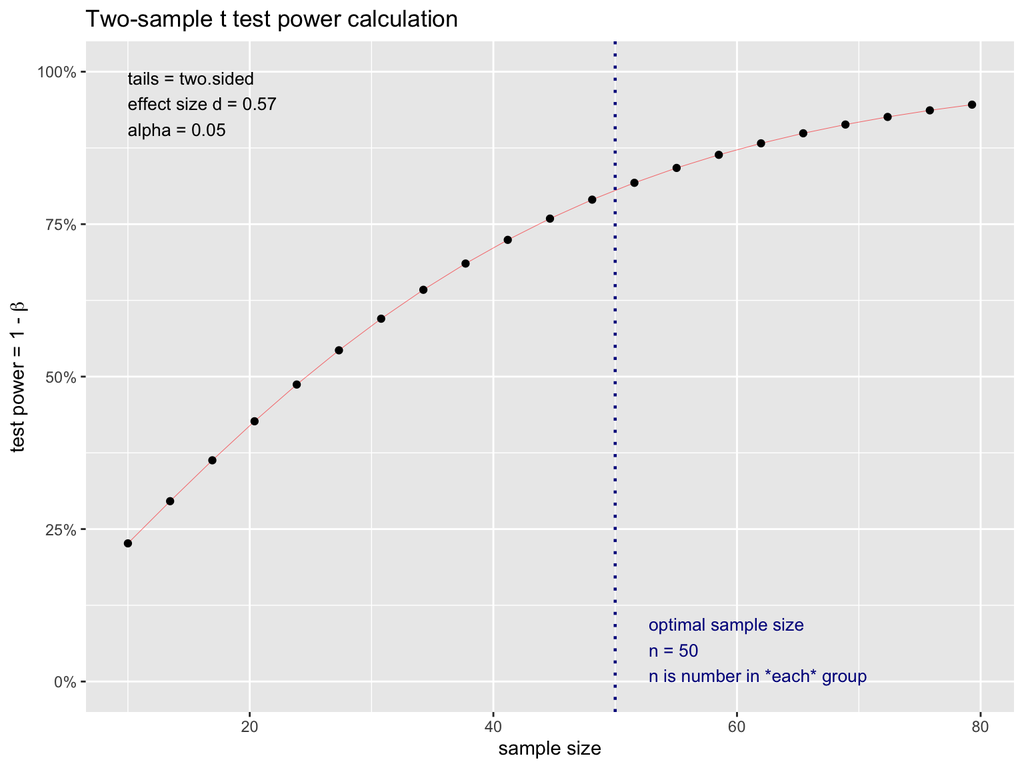

Figure 1: Power curve based on two-sample t test power calculation.

```r
power_plot <- pwr.t.test(d = 0.57, sig.level = 0.05, power = 0.80)

plot(power_plot)
```

## 8.3 Objectives

*Main objective*

To investigate the immunological effect of MV130 in Malawian adult population and its influence on pneumococcal colonisation.

*Secondary objectives*

1. To examine local and systemic innate, cellular responses to MV130 compared to placebo.
2. To examine the modulation of the immune effect on MV130 by experimental pneumococcal serotype 6B carriage.
3. To determine if MV130 treatment is protective against experimental pneumococcal serotype 6B carriage in healthy adults.
4. To determine the effect of compliance to MV130 on its immunological effects and colonisation by experimental strain 6B.

# 9 Data loading

To be able to do the analysis, we will need to read in the locked, unblinded data. We will then reformat the data to meet analysis needs.

That is what this section does - not visual output, just R code.

```r
randoDf<-read.csv("../Data/20260608/MV130_UNBLINIDNG_raw.csv")
screenDf<-read.csv("../Data/20260608/MV1301_SCREENING_label.csv")
visitDf<-read.csv("../Data/20260608/MV1302_Visits_raw.csv")
carriageDf<-read.csv("../Data/20260608/MV130_CARRIAGE_20250610.csv")
adhereDf<-read.csv("../Data/20260608/vmv130_adherence_raw.csv")
withdrawDf<-read.csv("../Data/20260608/MV1304_Withdraw_raw.csv")

screenDf<-screenDf %>% dplyr::filter(!(pid=="MV11054" & rid_verified==""))
  # PID MV11054 appears twice in data table; they tested positive for Covid-19 on their first visit 2024-10-31, and were rescreened on 2024-11-11 when they were negative and then recruited and randomised at that occasion; so will only use the data from the visit when they were randomised.

screenDf<-screenDf %>%
  dplyr::select(!bmi) %>% # bmi in database seems to be weight*height rather than weight/height^2
  dplyr::mutate(
    bmi=weight/height^2
  )

adhereDf$dayscomplete[adhereDf$pid=="MV10395"]<-41 # hard-coded; needs database update; see email from Vusi from 9 July 2025

withdrawDf<-withdrawDf %>%
  dplyr::filter(pid!="MV10346") # hard-coded fix to a mistaken entry into the withdrawal data frame; MV10346 showed up late but did get inoculated; see email from Lumbani from 29 July 2025

randoDf<-randoDf %>% dplyr::filter(!(pid=="MV11054" & rid_verified==""))
  # as per earlier note: PID MV11054 appears twice in data table; they tested positive for Covid-19 on their first visit 2024-10-31, and were rescreened on 2024-11-11 when they were negative and then recruited and randomised at that occasion; so will only use the data from the visit when they were randomised.

labNtrDf<-read.csv("../Data/20260604_NTR/MV130 Nasal Cellular Response_Revised-AK_GT_LM_04062026.csv")

labNtrDf<-labNtrDf %>%
  dplyr::mutate(
    Visit=factor(Visit,levels=c("D0","D14","D35","D44","D49")),
    PID_SID=paste(sep="_",PID,sid),
    PID_Visit=paste(sep="_",PID,Visit),
    neutroEpithRatio=Absolute.Neutrophil.Count/Absolute.Epithelial.Cell.Count,
    tcellEpithRatio=Absolute.T.cell.Count/Absolute.Epithelial.Cell.Count
  )

colnames(labNtrDf)[colnames(labNtrDf)=="Neutrophil.proportion.of.all.leukocytes...."]<-"neutroProp"
colnames(labNtrDf)[colnames(labNtrDf)=="T.cell.proportion.of.all.leukocytes...."]<-"tcellProp"

colnames(labNtrDf)[colnames(labNtrDf)=="Absolute.Neutrophil.Count"]<-"neutroAbs"
colnames(labNtrDf)[colnames(labNtrDf)=="Absolute.T.cell.Count"]<-"tcellAbs"

idxFailedQC<-which(labNtrDf$QC.Check=="FAILED")

labNtrDfFailedQC<-labNtrDf[idxFailedQC,]
if(length(idxFailedQC)>0){
  labNtrDf<-labNtrDf[-idxFailedQC,]
}

# removing genuine duplicates (totally identical records)
pidSidDup<-names(which(table(labNtrDf$PID_SID)>1))
tmp<-labNtrDf %>% dplyr::filter(PID_SID %in% pidSidDup)
tmp<-tmp[order(tmp$PID_SID),]

tmp %>%
  knitr::kable(caption="Verifying that records with duplicate PID & SID combination are genuine duplicates.")
```

Verifying that records with duplicate PID & SID combination are genuine duplicates.

| sid | PID | ARM | Visit | QC.Check | Beads.event.count | Nuetrophils.event.count | T.cell.event.count | Epithelial.cell.event.count | neutroProp | tcellProp | Epithelial.cell.proportion.of.all.non.leukocytes…. | NTR | Epithelial.cell.to.T.cell.Ratio..ETR. | neutroAbs | tcellAbs | Absolute.Epithelial.Cell.Count | CYTOMETER | X | PID_SID | PID_Visit | neutroEpithRatio | tcellEpithRatio |
| --- | --- | --- | --- | --- | --- | --- | --- | --- | --- | --- | --- | --- | --- | --- | --- | --- | --- | --- | --- | --- | --- | --- |

```r
idxDupRm<-integer(0)
for(dup in pidSidDup){
  idxTmp<-which(labNtrDf$PID_SID==dup)
  idxDupRm<-c(idxDupRm,idxTmp[2])
}

if(length(idxDupRm)>0){
  labNtrDf<-labNtrDf[-idxDupRm,]
}

# checking for participants with more than one sample for a given visit
pidVisitMult<-names(which(table(labNtrDf$PID_Visit)>1))

tmp<-labNtrDf %>% dplyr::filter(PID_Visit %in% pidVisitMult)
tmp<-tmp[order(tmp$PID_Visit),]

tmp %>%
  knitr::kable(caption="Verifying observations for participant-visit pairs with more than one sample.")
```

Verifying observations for participant-visit pairs with more than one sample.

| sid | PID | ARM | Visit | QC.Check | Beads.event.count | Nuetrophils.event.count | T.cell.event.count | Epithelial.cell.event.count | neutroProp | tcellProp | Epithelial.cell.proportion.of.all.non.leukocytes…. | NTR | Epithelial.cell.to.T.cell.Ratio..ETR. | neutroAbs | tcellAbs | Absolute.Epithelial.Cell.Count | CYTOMETER | X | PID_SID | PID_Visit | neutroEpithRatio | tcellEpithRatio |
| --- | --- | --- | --- | --- | --- | --- | --- | --- | --- | --- | --- | --- | --- | --- | --- | --- | --- | --- | --- | --- | --- | --- |
| DFU172 | MV11054 | MV130 | D0 | PASSED | 11766 | 30196 | 39219 | 16363 | 31.4 | 40.8 | 12.9 | 0.7696078 | 0.3161765 | 53.380656 | 69.331565 | 28.926602 | FACSAriaIII |  | MV11054_DFU172 | MV11054_D0 | 1.8453829 | 2.3968099 |
| DFU17K | MV11054 | MV130 | D0 | PASSED | 14540 | 1445 | 3637 | 6678 | 18.7 | 47.1 | 20.9 | 0.3970276 | 0.4437367 | 2.067125 | 5.202861 | 9.553122 | FACSAriaIII |  | MV11054_DFU17K | MV11054_D0 | 0.2163822 | 0.5446241 |

```r
# This duplicated sample involved the screening sample for participant MV11054 -- see earlier notes abou this participant and their two screening visits; resolution: remove sample ID DFU172 as this was from the first visit (2024-10-31) when the participant had tested positive for Covid-19; the second sample DFU17K (2024-11-11) was when the participant was rescreened and Covid-19 negative
labNtrDf<-labNtrDf %>% dplyr::filter(sid!="DFU172")

if(sum(table(labNtrDf$PID_Visit)>1)>0){stop("Warning: duplicated PID_Visit values.")}

labNtrDf<-labNtrDf %>%
  dplyr::mutate(
    NTRDiff=abs(NTR-Nuetrophils.event.count/T.cell.event.count),
  ) %>%
  dplyr::mutate(
    NTRcheck=Nuetrophils.event.count/T.cell.event.count
  )
# NTR is fully reproducible!

labNtrWideDf<-labNtrDf[order(decreasing=F,labNtrDf$Visit),] %>%
  dplyr::select(PID,Visit,NTR,neutroAbs,neutroProp,neutroEpithRatio,tcellAbs,tcellProp,tcellEpithRatio) %>%
  tidyr::pivot_wider(id_cols=PID,names_from=Visit,values_from=c(NTR, starts_with("neutro"), starts_with("tcell")))

# consortDf<-read_xlsx("../Data/20250618/MV130_CONSORT.xlsx")
# consortDf<-consortDf %>% dplyr::filter(grepl(pattern="MV",PIDs))
# consortPIDs<-consortDf$PIDs[consortDf$`Grand Total`==7 & is.na(consortDf$withdrawn)]

uniquePIDs<-sort(unique(c(randoDf$pid,screenDf$pid,visitDf$pid,carriageDf$IdNumber,adhereDf$pid,withdrawDf$pid)))

mv130df<-data.frame(
  pid=uniquePIDs
) %>%
  dplyr::left_join(y=screenDf %>% dplyr::select(pid,rid_verified,gender,age,bmi,smoking,chichewa,english,fridge,hiv,pneumovac,under5,over65,chronicillness,hivnoart,advancedhiv,pallergy,acuteill,respdisease,cardiacdisease,liverdisease,renaldisease,cancer,chealthcond,medications,pregnancy,pregnancyplan,clinstudy,alcohol,smoking,w_consent),by="pid") %>%
  dplyr::left_join(y=randoDf %>% dplyr::select(pid,treat_name),by="pid") %>%
  dplyr::mutate(
    studyArm=factor(treat_name,levels=c("Placebo","MV130")),
    sex=gender,
    rid=rid_verified
  ) %>%
  dplyr::select(!c(treat_name,gender,rid_verified)) %>%
  dplyr::mutate(
    enrolled=NA,
    withdrawn=ifelse(pid %in% withdrawDf$pid,1,0),
    analysisPopulation=NA,
    complianceSelf=factor(levels=c("Non-compliant","Compliant"),ifelse(adhereDf$dayscomplete>=38,"Compliant","Non-compliant")[match(pid,adhereDf$pid)]), # >=90% compliant with respect to days reported to have taken the treatment (100% corresponds to 42 days)
    complianceBw=factor(levels=c("Non-compliant","Compliant"),ifelse(adhereDf$bottleweight<=30,"Compliant","Non-compliant")[match(pid,adhereDf$pid)]), # >=90% compliant on bottleweight; target weight should be 29g; initial bottle weight was 39g, 10g corresponds to full 84 sprays taken; 90% compliance corresponds to 9g sprayed, so final bottleweight should be 30g or less
    compliance=factor(levels=c("Non-compliant","Compliant"),ifelse(adhereDf$dayscomplete>=38 & adhereDf$bottleweight<=30,"Compliant","Non-compliant")[match(pid,adhereDf$pid)]),
    carriageD0=NA,
    carriageD0_density=NA,
    carriageD14=NA,
    carriageD14_density=NA,
    carriageD21=NA,
    carriageD21_density=NA,
    carriageD44=NA,
    carriageD44_density=NA,
    carriageD44_6B=NA,
    carriageD0_6B_density=NA,
    carriageD49=NA,
    carriageD49_density=NA,
    carriageD49_6B=NA,
    carriageD49_6B_density=NA,
    ntrDay0=NA,
    ntrDay14=NA,
    ntrDay35=NA,
    ntrDay44=NA,
    ntrDay49=NA,
    smokingHistory=case_when(
      smoking==1~"Never smoked",
      smoking==2~"Current regular smoker",
      smoking==3~"Current irregular smoker",
      smoking==4~"Ex-smoker who gave up within past 6 months",
      smoking==5~"Ex-smoker who gave up more than 6 months ago with more than 10 pack-year history",
      smoking==6~"Ex-smoker who gave up more than 6 months ago with less than 10 pack-year history",
      TRUE~NA_character_
    )
  ) %>%
  dplyr::mutate(
    enrolled=ifelse(!is.na(rid) & rid!="",1,0),
    inoculated=ifelse(pid %in% c(visitDf$pid[visitDf$visit==4 & visitDf$inoculation_complete==1],"MV10148"),1,0) # hard-coded; requires database update; see email from Lumbani from 28 July 2025
  )

for(i in 1:nrow(mv130df)){
  if(sum(carriageDf$Visit=="Visit B" & carriageDf$IdNumber==mv130df$pid[i])==1){
    mv130df$carriageD0[i]<-carriageDf$Result[carriageDf$Visit=="Visit B" & carriageDf$IdNumber==mv130df$pid[i]]
    mv130df$carriageD0_density[i]<-carriageDf$density[carriageDf$Visit=="Visit B" & carriageDf$IdNumber==mv130df$pid[i]]
  }
  if(sum(carriageDf$Visit=="Visit B1" & carriageDf$IdNumber==mv130df$pid[i])==1){
    mv130df$carriageD14[i]<-carriageDf$Result[carriageDf$Visit=="Visit B1" & carriageDf$IdNumber==mv130df$pid[i]]
    mv130df$carriageD14_density[i]<-carriageDf$density[carriageDf$Visit=="Visit B1" & carriageDf$IdNumber==mv130df$pid[i]]
  }
  if(sum(carriageDf$Visit=="Visit C" & carriageDf$IdNumber==mv130df$pid[i])==1){
    mv130df$carriageD21[i]<-carriageDf$Result[carriageDf$Visit=="Visit C" & carriageDf$IdNumber==mv130df$pid[i]]
    mv130df$carriageD21_density[i]<-carriageDf$density[carriageDf$Visit=="Visit C" & carriageDf$IdNumber==mv130df$pid[i]]
  }
  if(sum(carriageDf$Visit=="Visit E" & carriageDf$IdNumber==mv130df$pid[i])==1){
    mv130df$carriageD44[i]<-carriageDf$Result[carriageDf$Visit=="Visit E" & carriageDf$IdNumber==mv130df$pid[i]]
    mv130df$carriageD44_density[i]<-carriageDf$density[carriageDf$Visit=="Visit E" & carriageDf$IdNumber==mv130df$pid[i]]
  }
  if(sum(carriageDf$Visit=="Visit F" & carriageDf$IdNumber==mv130df$pid[i])==1){
    mv130df$carriageD49[i]<-carriageDf$Result[carriageDf$Visit=="Visit F" & carriageDf$IdNumber==mv130df$pid[i]]
    mv130df$carriageD49_density[i]<-carriageDf$density[carriageDf$Visit=="Visit F" & carriageDf$IdNumber==mv130df$pid[i]]
  }
}

pneumoStrainsNot6B<-c("NVT","1","3","4","6A","7","7F","8","9","9V","14","15","17","18C","19","19A","19F","20","23","23F")

mv130df<-mv130df %>%
  dplyr::mutate(
    carriageD0_NC=case_when(
      carriageD0 %in% c("No Growth","Growth, Not Strep pneumoniae")~0,
      carriageD0 %in% c(pneumoStrainsNot6B,"6B")~1,
      TRUE~NA_integer_),
    carriageD14_NC=case_when(
      carriageD14 %in% c("No Growth","Growth, Not Strep pneumoniae")~0,
      carriageD14 %in% c(pneumoStrainsNot6B,"6B")~1,
      TRUE~NA_integer_),
    carriageD21_NC=case_when(
      carriageD21 %in% c("No Growth","Growth, Not Strep pneumoniae")~0,
      carriageD21 %in% c(pneumoStrainsNot6B,"6B")~1,
      TRUE~NA_integer_),
    carriageD44_6B=case_when(
      carriageD44=="6B"~1,
      carriageD44!="6B"~0,
      TRUE~NA_integer_),
    carriageD44_NC=case_when(
      carriageD44 %in% c("No Growth","Growth, Not Strep pneumoniae","6B")~0,
      carriageD44 %in% pneumoStrainsNot6B~1,
      TRUE~NA_integer_),
    carriageD49_6B=case_when(
      carriageD49=="6B"~1,
      carriageD49!="6B"~0,
      TRUE~NA_integer_),
    carriageD49_NC=case_when(
      carriageD49 %in% c("No Growth","Growth, Not Strep pneumoniae","6B")~0,
      carriageD49 %in% pneumoStrainsNot6B~1,
      TRUE~NA_integer_),
    carriage_6B=case_when(
      carriageD44=="6B" | carriageD49=="6B"~"yes",
      carriageD44!="6B" & carriageD49!="6B"~"no",
      TRUE~NA_character_),
    ntrDay0=labNtrWideDf$NTR_D0[match(pid,labNtrWideDf$PID)],
    ntrDay14=labNtrWideDf$NTR_D14[match(pid,labNtrWideDf$PID)],
    ntrDay35=labNtrWideDf$NTR_D35[match(pid,labNtrWideDf$PID)],
    ntrDay44=labNtrWideDf$NTR_D44[match(pid,labNtrWideDf$PID)],
    ntrDay49=labNtrWideDf$NTR_D49[match(pid,labNtrWideDf$PID)],
    neutroPropDay0=labNtrWideDf$neutroProp_D0[match(pid,labNtrWideDf$PID)],
    neutroPropDay14=labNtrWideDf$neutroProp_D14[match(pid,labNtrWideDf$PID)],
    neutroPropDay35=labNtrWideDf$neutroProp_D35[match(pid,labNtrWideDf$PID)],
    neutroPropDay44=labNtrWideDf$neutroProp_D44[match(pid,labNtrWideDf$PID)],
    neutroPropDay49=labNtrWideDf$neutroProp_D49[match(pid,labNtrWideDf$PID)],
    neutroAbsDay0=labNtrWideDf$neutroAbs_D0[match(pid,labNtrWideDf$PID)],
    neutroAbsDay14=labNtrWideDf$neutroAbs_D14[match(pid,labNtrWideDf$PID)],
    neutroAbsDay35=labNtrWideDf$neutroAbs_D35[match(pid,labNtrWideDf$PID)],
    neutroAbsDay44=labNtrWideDf$neutroAbs_D44[match(pid,labNtrWideDf$PID)],
    neutroAbsDay49=labNtrWideDf$neutroAbs_D49[match(pid,labNtrWideDf$PID)],
    neutroEpithRatioDay0=labNtrWideDf$neutroEpithRatio_D0[match(pid,labNtrWideDf$PID)],
    neutroEpithRatioDay14=labNtrWideDf$neutroEpithRatio_D14[match(pid,labNtrWideDf$PID)],
    neutroEpithRatioDay35=labNtrWideDf$neutroEpithRatio_D35[match(pid,labNtrWideDf$PID)],
    neutroEpithRatioDay44=labNtrWideDf$neutroEpithRatio_D44[match(pid,labNtrWideDf$PID)],
    neutroEpithRatioDay49=labNtrWideDf$neutroEpithRatio_D49[match(pid,labNtrWideDf$PID)],
    tcellPropDay0=labNtrWideDf$tcellProp_D0[match(pid,labNtrWideDf$PID)],
    tcellPropDay14=labNtrWideDf$tcellProp_D14[match(pid,labNtrWideDf$PID)],
    tcellPropDay35=labNtrWideDf$tcellProp_D35[match(pid,labNtrWideDf$PID)],
    tcellPropDay44=labNtrWideDf$tcellProp_D44[match(pid,labNtrWideDf$PID)],
    tcellPropDay49=labNtrWideDf$tcellProp_D49[match(pid,labNtrWideDf$PID)],
    tcellAbsDay0=labNtrWideDf$tcellAbs_D0[match(pid,labNtrWideDf$PID)],
    tcellAbsDay14=labNtrWideDf$tcellAbs_D14[match(pid,labNtrWideDf$PID)],
    tcellAbsDay35=labNtrWideDf$tcellAbs_D35[match(pid,labNtrWideDf$PID)],
    tcellAbsDay44=labNtrWideDf$tcellAbs_D44[match(pid,labNtrWideDf$PID)],
    tcellAbsDay49=labNtrWideDf$tcellAbs_D49[match(pid,labNtrWideDf$PID)],
    tcellEpithRatioDay0=labNtrWideDf$tcellEpithRatio_D0[match(pid,labNtrWideDf$PID)],
    tcellEpithRatioDay14=labNtrWideDf$tcellEpithRatio_D14[match(pid,labNtrWideDf$PID)],
    tcellEpithRatioDay35=labNtrWideDf$tcellEpithRatio_D35[match(pid,labNtrWideDf$PID)],
    tcellEpithRatioDay44=labNtrWideDf$tcellEpithRatio_D44[match(pid,labNtrWideDf$PID)],
    tcellEpithRatioDay49=labNtrWideDf$tcellEpithRatio_D49[match(pid,labNtrWideDf$PID)],
  ) %>%
  dplyr::mutate(
    carriageD0_NC_density=case_when(
      carriageD0_NC==1~carriageD0_density,
      TRUE~NA_real_
    ),
    carriageD14_NC_density=case_when(
      carriageD14_NC==1~carriageD14_density,
      TRUE~NA_real_
    ),
    carriageD21_NC_density=case_when(
      carriageD21_NC==1~carriageD21_density,
      TRUE~NA_real_
    ),
    carriageD44_6B_density=case_when(
      carriageD44_6B==1~carriageD44_density,
      TRUE~NA_real_
    ),
    carriageD44_NC_density=case_when(
      carriageD44_NC==1~carriageD44_density,
      TRUE~NA_real_
    ),
    carriageD49_6B_density=case_when(
      carriageD49_6B==1~carriageD49_density,
      TRUE~NA_real_
    ),
    carriageD49_NC_density=case_when(
      carriageD49_NC==1~carriageD49_density,
      TRUE~NA_real_
    ),
  )
```

```r
# idxBadAge<-which(is.na(mv130df$age) | mv130df$age<18 | mv130df$age>40)
# idxNoLanguageForConsent<-which((is.na(screenDf$chichewa) | screenDf$chichewa %in% c("","No")) & (is.na(screenDf$english) | screenDf$english==0))
# idxPreviousPneumoVacc<-which(is.na(screenDf$pneumovac) | screenDf$pneumovac %in% c("","Yes"))
# idxHiv<-which(is.na(screenDf$hiv) | screenDf$hiv==1)
# idxCloseContactUnder5<-which(is.na(screenDf$under5) | screenDf$under5==1)
# idxCloseContactOver65<-which(is.na(screenDf$over65) | screenDf$over65==1)
# idxCloseContactChronicIll<-which(is.na(screenDf$chronicillness) | screenDf$chronicillness==1)
# idxCloseContactHivNoART<-which(is.na(screenDf$hivnoart) | screenDf$hivnoart==1)
# idxCloseContactHivAdvanced<-which(is.na(screenDf$advancedhiv) | screenDf$advancedhiv==1)
# idxCloseContactPenicillinAllergy<-which(is.na(screenDf$pallergy) | screenDf$pallergy %in% c("","Yes"))

tmpVisits<-visitDf %>%
  dplyr::group_by(pid) %>%
  dplyr::summarise(nVisits=n(),.groups="drop")

mv130df<-mv130df %>%
  dplyr::mutate(
    nVisits=tmpVisits$nVisits[match(pid,tmpVisits$pid)],
    eligibleAge=case_when(
      is.na(age) | age<18 | age>40 ~ FALSE,
      TRUE~TRUE
    ),
    eligibleLanguage=case_when(
      (is.na(chichewa) | chichewa %in% c("","No")) & (is.na(english) | english==0) ~ FALSE,
      TRUE~TRUE
    ),
    eligibleFridge=case_when(
      is.na(fridge) | fridge %in% c("","No") ~ FALSE,
      TRUE~TRUE
    ),
    eligibleContraception=case_when( ## double-check with DMSU,
      (is.na(sex) | sex=="Female") & (is.na(pregnancyplan) | pregnancyplan==1) ~ FALSE,
      TRUE~TRUE
    ),
    eligiblePriorPneumoVacc=case_when(
      is.na(pneumovac) | pneumovac %in% c("","Yes") ~ FALSE,
      TRUE~TRUE
    ),
    eligibleHiv=case_when(
      is.na(hiv) | hiv==1 ~ FALSE,
      TRUE~TRUE
    ),
    eligibleCloseContactUnder5=case_when(
      is.na(under5) | under5==1 ~ FALSE,
      TRUE~TRUE
    ),
    eligibleCloseContactOver65=case_when(
      is.na(over65) | over65==1 ~ FALSE,
      TRUE~TRUE
    ),
    eligibleCloseContactChronicIll=case_when(
      is.na(chronicillness) | chronicillness==1 ~ FALSE,
      TRUE~TRUE
    ),
    eligibleCloseContactHivNoART=case_when(
      is.na(hivnoart) | hivnoart==1 ~ FALSE,
      TRUE~TRUE
    ),
    eligibleCloseContactAdvancedHiv=case_when(
      is.na(advancedhiv) | advancedhiv==1 ~ FALSE,
      TRUE~TRUE
    ),
    eligiblePeniAmoxillinAllergy=case_when(
      is.na(pallergy) | pallergy %in% c("","Yes") ~ FALSE,
      TRUE~TRUE
    ),
    eligibleAcuteIllness=case_when(
      is.na(acuteill) | acuteill %in% c("","Yes") ~ FALSE,
      TRUE~TRUE
    ),
    eligibleChronicIllness=case_when(
      is.na(respdisease) | respdisease==1 | is.na(cardiacdisease) | cardiacdisease==1 | is.na(liverdisease) | liverdisease==1 | is.na(renaldisease) | renaldisease==1 | is.na(cancer) | cancer==1 | is.na(chealthcond) | chealthcond==1 ~ FALSE,
      TRUE~TRUE
    ),
    eligibleMedications=case_when( # need to double-check with DMSU
      is.na(medications) & pid=="MV10072"~TRUE, ## hard-coded; needs database update; see email from Lumbani from 28 July 2025
      is.na(medications) | medications==1 ~ FALSE,
      TRUE~TRUE
    ),
    eligiblePregnancy=case_when(
      (is.na(sex) | sex=="Female") & (is.na(pregnancy) | pregnancy==1) ~ FALSE,
      TRUE~TRUE
    ),
    eligibleOtherTrial=case_when(
      !is.na(clinstudy) & clinstudy=="No" ~ TRUE,
      TRUE~FALSE
    ),
    eligibleDrugAlcohol=case_when( # drug history seems to be missing??
      pid=="MV10072" ~ TRUE, # hard-coded; see email from Lumbani from 8 June 2026; should be corrected on database but is not yet the case
      pid!="MV10072" & (is.na(alcohol) | alcohol %in% 3:5) ~ FALSE,
      TRUE~TRUE
    ),
    eligibleSmoking=case_when(
      is.na(smoking) | smoking %in% c(2,4,5,6) ~ FALSE,
      TRUE~TRUE
    ),
    eligibleConsent=case_when(
      !is.na(w_consent) & w_consent=="Yes"~TRUE,
      TRUE~FALSE
    )
  ) %>%
  dplyr::mutate(
    eligible=case_when(
      eligibleAge & eligibleLanguage & eligibleFridge & eligibleContraception & eligiblePriorPneumoVacc & eligibleHiv & eligibleCloseContactUnder5 & eligibleCloseContactOver65 & eligibleCloseContactChronicIll & eligibleCloseContactHivNoART & eligibleCloseContactHivNoART & eligibleCloseContactAdvancedHiv & eligiblePeniAmoxillinAllergy & eligibleAcuteIllness & eligibleChronicIllness & eligibleMedications & eligiblePregnancy & eligibleOtherTrial & eligibleDrugAlcohol & eligibleSmoking & eligibleConsent~TRUE,
      TRUE~FALSE
    ),
    completedFollowUp=ifelse((pid %in% screenDf$pid & nVisits==6) | pid=="MV11054",TRUE,FALSE) # hard-coded MV11054 as having completed all visits; see email from Lumbani from 29 July 2025; their visit 2 was recorded on the screening form as they needed re-screening but they did their visit 2; see also earlier notes for this participant
  )

rm(tmpVisits)

withdrawDf<-withdrawDf %>%
  dplyr::mutate(
    reason=case_when(
      term_reas==1~"Withdrawal of consent",
      term_reas==2~"Developed COVID-19",
      term_reas==3~"Unwell and excluded by study clinician",
      term_reas==4~"Relocated",
      term_reas==5~"Lost to follow up",
      term_reas==6~"Died",
      term_reas==7~"Other",
      TRUE~NA_character_
    )
  )

mv130df<-mv130df %>%
  dplyr::mutate(
    reasonForWithdrawal=withdrawDf$reason[match(pid,withdrawDf$pid)],
    perProtocol=ifelse(withdrawn==0 & eligible & enrolled==1 & inoculated==1 & completedFollowUp==1,1,0)
  )

mv130df_pp<-mv130df %>%
  dplyr::filter(perProtocol==1)

# Issue with MV10072 who is ineligible on alcohol consumption grounds, but was enrolled, randomised and completed the study
```

# 10 Data Analysis

The R code to generate the results is embedded in this document. By default it is hidden, but can be displayed by clicking on the `Code` boxes on the right hand side.

The reporting of this study is prepared in accordance with the CONSORT 2025 guidelines (Hopewell et al. 2025).

## 10.1 Analysis population

The analysis population includes all eligible, enrolled & randomised participants who completed all study visits. These participants were analysed according to the study arm they were randomised to.

## 10.2 CONSORT diagram and participant characteristics.

```r
nScreened<-nrow(screenDf)

nEligible<-sum(mv130df$eligible)
ineligible<-character(0)
ineligibleAge<-mv130df$pid[!mv130df$eligibleAge]; ineligible<-c(ineligible,ineligibleAge)
ineligibleLanguage<-setdiff(mv130df$pid[!mv130df$eligibleLanguage],ineligible); ineligible<-c(ineligible,ineligibleLanguage)
ineligibleRefrigerator<-setdiff(mv130df$pid[!mv130df$eligibleFridge],ineligible); ineligible<-c(ineligible,ineligibleRefrigerator)
ineligibleContraception<-setdiff(mv130df$pid[!mv130df$eligibleContraception],ineligible); ineligible<-c(ineligible,ineligibleContraception)
ineligiblePriorPneumoVacc<-setdiff(mv130df$pid[!mv130df$eligiblePriorPneumoVacc],ineligible); ineligible<-c(ineligible,ineligiblePriorPneumoVacc)
ineligibleHiv<-setdiff(mv130df$pid[!mv130df$eligibleHiv],ineligible); ineligible<-c(ineligible,ineligibleHiv)
ineligibleCloseContact<-setdiff(mv130df$pid[!mv130df$eligibleCloseContactUnder5 | !mv130df$eligibleCloseContactOver65 | !mv130df$eligibleCloseContactChronicIll | !mv130df$eligibleCloseContactHivNoART | !mv130df$eligibleCloseContactAdvancedHiv],ineligible)
ineligiblePeniAmoxillinAllergy<-setdiff(mv130df$pid[!mv130df$eligiblePeniAmoxillinAllergy],ineligible); ineligible<-c(ineligible,ineligiblePeniAmoxillinAllergy)
ineligibleAcuteIllness<-setdiff(mv130df$pid[!mv130df$eligibleAcuteIllness],ineligible); ineligible<-c(ineligible,ineligibleAcuteIllness)
ineligibleChronicIllness<-setdiff(mv130df$pid[!mv130df$eligibleChronicIllness],ineligible); ineligible<-c(ineligible,ineligibleChronicIllness)
ineligibleMedications<-setdiff(mv130df$pid[!mv130df$eligibleMedications],ineligible); ineligible<-c(ineligible,ineligibleMedications)
ineligiblePregnancy<-setdiff(mv130df$pid[!mv130df$eligiblePregnancy],ineligible); ineligible<-c(ineligible,ineligiblePregnancy)
ineligibleOtherTrial<-setdiff(mv130df$pid[!mv130df$eligibleOtherTrial],ineligible); ineligible<-c(ineligible,ineligibleOtherTrial)
ineligibleDrugAlcohol<-setdiff(mv130df$pid[!mv130df$eligibleDrugAlcohol],ineligible); ineligible<-c(ineligible,ineligibleDrugAlcohol)
ineligibleSmoking<-setdiff(mv130df$pid[!mv130df$eligibleSmoking],ineligible); ineligible<-c(ineligible,ineligibleSmoking)

noConsent<-setdiff(mv130df$pid[!mv130df$eligibleConsent],ineligible)

nRandomised<-sum(mv130df$enrolled)
```

Numbers for the CONSORT diagram:

- Screened: 118
- Eligible: 107
  - Not eligible - <18 or >40: 2
  - Not eligible - not speaking/reading Chichewa or English: 0
  - Not eligible - not having access to a refrigerator: 0
  - Not eligible - female and not willing to take contraception during study: 9
  - Not eligible - prior pneumococcal vaccination/immunotherapy or previous participant in a pneumococcal CHIM: 0
  - Not eligible - PLHIV: 0
  - Not eligible - close contact with at-risk individuals: 0
  - Not eligible - allergy to penicillin/amoxicillin: 0
  - Not eligible - acute illness: 0
  - Not eligible - chronic illness: 0
  - Not eligible - on immunosuppresive medication: 0
  - Not eligible - pregnancy: 0
  - Not eligible - enrolled in another clinical trial: 0
  - Not eligible - history of drug or alcohol abuse: 0
  - Not eligible - history of smoking: 0
  - Did not consent: 0
- Randomised: 107
  - Randomised to MV130: 57
  - Randomised to Placebo: 50
- Lost to follow-up / withdrawn between randomisation and inoculation: 8
  - MV130 arm: 4
    - Developed COVID-19: 0
    - Relocated: 1
    - Lost-to-follow-up: 2
    - Other: 1
  - Placebo arm: 4
    - Developed COVID-19: 0
    - Relocated: 0
    - Lost-to-follow-up: 0
    - Other: 4
- Inoculated: 99
  - MV130 arm: 53
  - Placebo arm: 46
- Completed all study visits: 96
  - MV130 arm: 52
    - Developed COVID-19: 1
    - Relocated: 0
    - Lost-to-follow-up: 0
    - Other: 0
  - Placebo arm: 44
    - Developed COVID-19: 0
    - Relocated: 0
    - Lost-to-follow-up: 1
    - Other: 1
- Included in analysis: 96
  - MV130 arm: 52
  - Placebo arm: 44

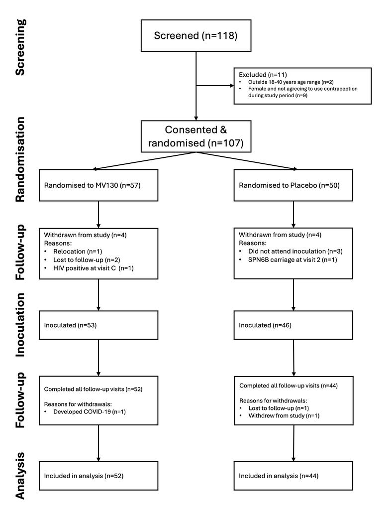

Figure 2: CONSORT diagram for the MV130 trial (simplified).

```r
include_graphics("../CONSORT/MV130_ConsortDiagram_20260615_BritishEnglish.png")
```

## 10.3 Participant characteristics

We present the baseline characteristics of study participants at screening, including demographics, physiological measures, and lifestyle factors. These characteristics provide an overview of the study population. Table 4.

```r
mv130df_pp$studyArm <- factor(mv130df_pp$studyArm, levels = c("MV130","Placebo"))

sumFun <- function(.data) {
  .data %>%
    dplyr::summarise(
      n = n(),
      sexMale = sum(na.rm = TRUE, sex == "Male"),
      sexMaleProp = sum(na.rm = TRUE, sex == "Male") / sum(!is.na(sex)),
      ageMedian = median(na.rm = TRUE, age),
      age25th = quantile(na.rm = TRUE, age, probs = 0.25),
      age75th = quantile(na.rm = TRUE, age, probs = 0.75),
      BMIMedian = median(na.rm = TRUE, bmi),
      BMI25th = quantile(na.rm = TRUE, bmi, probs = 0.25),
      BMI75th = quantile(na.rm = TRUE, bmi, probs = 0.75),
      smokingNever = sum(na.rm = TRUE, smokingHistory == "Never smoked"),
      smokingNeverProp = sum(na.rm = TRUE, smokingHistory == "Never smoked") / sum(!is.na(smokingHistory)),
      smokingPast = sum(na.rm = TRUE, grepl(smokingHistory,pattern="Ex-smoker")),
      smokingPastProp = sum(na.rm = TRUE, grepl(smokingHistory,pattern="Ex-smoker")) / sum(!is.na(smokingHistory)),
      smokingCurrent = sum(na.rm = TRUE, grepl(smokingHistory,pattern="Current")),
      smokingCurrentProp = sum(na.rm = TRUE, grepl(smokingHistory,pattern="Current")) / sum(!is.na(smokingHistory)),
      .groups = "drop"
    )
}

reformatFun<-function(dat,var,type,rowIdx,roundDigits=NULL){
  # type needs to be one of "medianIQR", "meanSD", "nProp"
  if(type=="medianIQR"){
    if(is.null(roundDigits)){roundDigits=2}
    tmp<-as.numeric(dat[rowIdx,paste(sep="",var,c("Median","25th","75th"))])
    tmp<-c(format(nsmall=roundDigits,round(tmp[1],digits=roundDigits)),paste(sep="","(",format(nsmall=roundDigits,round(tmp[2],digits=roundDigits)),",",format(nsmall=roundDigits,round(tmp[3],digits=roundDigits)),")"))
  }else if(type=="meanSD"){
    if(is.null(roundDigits)){roundDigits=2}
    tmp<-as.numeric(dat[rowIdx,paste(sep="",var,c("Mean","Sd"))])
    tmp<-c(format(nsmall=roundDigits,round(tmp[1],digits=roundDigits)),paste(sep="","(",format(nsmall=roundDigits,round(tmp[2],digits=roundDigits)),")"))
  }else if(type=="nProp"){
    if(is.null(roundDigits)){roundDigits=1}
    tmp<-as.numeric(dat[rowIdx,paste(sep="",var,c("","Prop"))])
    tmp<-c(tmp[1],paste(sep="","(",format(nsmall=roundDigits,round(100*tmp[2],digits=roundDigits)),"%)"))
  }

  return(tmp)
}

demoDatAll<-mv130df_pp %>%
 sumFun()

demoDatByVacc<-mv130df_pp %>%
  group_by(studyArm) %>%
  sumFun()

# Reformat the results table
demoDatKable <- data.frame(
  variable = c("Screened participants", "Enrolled participants", "Included in the analysis", "Sex: male", "Age", "BMI",
               "Smoking status: never smoker", "Smoking status: past smoker", "Smoking status: current smoker"),
  statistics = c("n (% out of total screened)", "n (% out of total enrolled)", "n (% out of total completed)", "n (%)", "median (IQR)", "median (IQR)",
                 "n (%)", "n (%)", "n (%)"),
  Astat1 = NA,  # Placeholder for values to be filled
  Astat2 = NA,  # Placeholder for values to be filled
  Vstat1 = NA,  # Placeholder for values to be filled
  Vstat2 = NA,  # Placeholder for values to be filled
  Cstat1 = NA,  # Placeholder for values to be filled
  Cstat2 = NA   # Placeholder for values to be filled
)


demoDatKable[demoDatKable$variable=="Screened participants",-c(1:2)]<-
  c(nrow(mv130df),
    paste(sep="","(",format(nsmall=1,round(100*nrow(mv130df)/nrow(mv130df),digits=1)),"%)"),NA,NA,NA,NA)

demoDatKable[demoDatKable$variable=="Enrolled participants",-c(1:2)]<-c(sum(mv130df$enrolled==1),
                           paste(sep="","(",format(nsmall=1,round(100*sum(mv130df$enrolled==1)/sum(mv130df$enrolled==1),digits=1)),"%)"),
                           sum(mv130df$enrolled==1 & mv130df$studyArm=="MV130",na.rm=TRUE),
                           paste(sep="","(",format(nsmall=1,round(100*sum(mv130df$studyArm=="MV130",na.rm=TRUE)/sum(mv130df$enrolled==1),digits=1)),"%)"),
                           sum(mv130df$enrolled==1 & mv130df$studyArm=="Placebo",na.rm=TRUE),
                           paste(sep="","(",format(nsmall=1,round(100*sum(mv130df$studyArm=="Placebo",na.rm=TRUE)/sum(mv130df$enrolled==1),digits=1)),"%)"))

demoDatKable[demoDatKable$variable=="Included in the analysis",-c(1:2)]<-c(sum(rowSums(is.na(mv130df_pp[,c("pid","age")]))==0),
                           paste(sep="","(",format(nsmall=1,round(100*sum(rowSums(is.na(mv130df_pp[,c("pid","age")]))==0)/nrow(mv130df_pp),digits=1)),"%)"),
                           sum(rowSums(is.na(mv130df_pp[mv130df_pp$studyArm=="MV130",c("pid","age")]))==0),
                           paste(sep="","(",format(nsmall=1,round(100*sum(rowSums(is.na(mv130df_pp[mv130df_pp$studyArm=="MV130",c("pid","age")]))==0)/nrow(mv130df_pp),digits=1)),"%)"),
                           sum(rowSums(is.na(mv130df_pp[mv130df_pp$studyArm=="Placebo",c("pid","age")]))==0),
                           paste(sep="","(",format(nsmall=1,round(100*sum(rowSums(is.na(mv130df_pp[mv130df_pp$studyArm=="Placebo",c("pid","age")]))==0)/nrow(mv130df_pp),digits=1)),"%)"))

demoDatKable[demoDatKable$variable=="Sex: male",-c(1:2)]<-c(reformatFun(dat=demoDatAll,var="sexMale",type="nProp",rowIdx=1),reformatFun(dat=demoDatByVacc,var="sexMale",type="nProp",rowIdx=1),reformatFun(dat=demoDatByVacc,var="sexMale",type="nProp",rowIdx=2))

demoDatKable[demoDatKable$variable=="Age",-c(1:2)]<-c(reformatFun(dat=demoDatAll,var="age",type="medianIQR",rowIdx=1),reformatFun(dat=demoDatByVacc,var="age",type="medianIQR",rowIdx=1),reformatFun(dat=demoDatByVacc,var="age",type="medianIQR",rowIdx=2))

demoDatKable[demoDatKable$variable=="BMI",-c(1:2)]<-c(reformatFun(dat=demoDatAll,var="BMI",type="medianIQR",rowIdx=1),reformatFun(dat=demoDatByVacc,var="BMI",type="medianIQR",rowIdx=1),reformatFun(dat=demoDatByVacc,var="BMI",type="medianIQR",rowIdx=2))

demoDatKable[demoDatKable$variable=="Smoking status: never smoker",-c(1:2)]<-c(reformatFun(dat=demoDatAll,var="smokingNever",type="nProp",rowIdx=1),reformatFun(dat=demoDatByVacc,var="smokingNever",type="nProp",rowIdx=1),reformatFun(dat=demoDatByVacc,var="smokingNever",type="nProp",rowIdx=2))
demoDatKable[demoDatKable$variable=="Smoking status: past smoker",-c(1:2)]<-c(reformatFun(dat=demoDatAll,var="smokingPast",type="nProp",rowIdx=1),reformatFun(dat=demoDatByVacc,var="smokingPast",type="nProp",rowIdx=1),reformatFun(dat=demoDatByVacc,var="smokingPast",type="nProp",rowIdx=2))
demoDatKable[demoDatKable$variable=="Smoking status: current smoker",-c(1:2)]<-c(reformatFun(dat=demoDatAll,var="smokingCurrent",type="nProp",rowIdx=1),reformatFun(dat=demoDatByVacc,var="smokingCurrent",type="nProp",rowIdx=1),reformatFun(dat=demoDatByVacc,var="smokingCurrent",type="nProp",rowIdx=2))

demoDatKable %>%
  kbl(col.names=rep("",ncol(demoDatKable)),caption="Participant characteristics. For variables in the demographics, physiology and life style sections, the percentages are out of the total participants included in the analysis for the respective study arms, whereas for the variables in the study characteristics section, the percentages are out of all participants at that study stage.") %>%
  kable_styling(full_width=F) %>%
  add_header_above(c(" "," ","All"=2,"MV-130"=2,"Placebo"=2)) %>%
  pack_rows("Study characteristics",1,3) %>%
  pack_rows("Demographics",4,5) %>%
  pack_rows("Physiology",6,6) %>%
  pack_rows("Life style",7,9)
```

Table 4: Participants characteristics

Participant characteristics. For variables in the demographics, physiology and life style sections, the percentages are out of the total participants included in the analysis for the respective study arms, whereas for the variables in the study characteristics section, the percentages are out of all participants at that study stage.

|  |  | All | All | MV-130 | MV-130 | Placebo | Placebo |
| --- | --- | --- | --- | --- | --- | --- | --- |
| **Study characteristics** |  |  |  |  |  |  |  |
| Screened participants | n (% out of total screened) | 118 | (100.0%) |  |  |  |  |
| Enrolled participants | n (% out of total enrolled) | 107 | (100.0%) | 57 | (53.3%) | 50 | (46.7%) |
| Included in the analysis | n (% out of total completed) | 96 | (100.0%) | 52 | (54.2%) | 44 | (45.8%) |
| **Demographics** |  |  |  |  |  |  |  |
| Sex: male | n (%) | 53 | (55.2%) | 25 | (48.1%) | 28 | (63.6%) |
| Age | median (IQR) | 26.85 | (23.75,30.12) | 26.86 | (23.42,29.75) | 26.75 | (23.98,31.14) |
| **Physiology** |  |  |  |  |  |  |  |
| BMI | median (IQR) | 22.53 | (20.76,25.06) | 23.27 | (20.67,25.27) | 22.20 | (20.81,24.83) |
| **Life style** |  |  |  |  |  |  |  |
| Smoking status: never smoker | n (%) | 94 | (97.9%) | 51 | (98.1%) | 43 | (97.7%) |
| Smoking status: past smoker | n (%) | 0 | (0.0%) | 0 | (0.0%) | 0 | (0.0%) |
| Smoking status: current smoker | n (%) | 2 | (2.1%) | 1 | (1.9%) | 1 | (2.3%) |

## 10.4 Study endpoints

We summarise the distributions of study endpoints (an experimental carriage, day 2 and day7 post-inoculation experimental carriage, NTR at day 0, 14 and 35) in a descriptive statistics table.

```r
sumFunEP <- function(.data) {
  .data %>%
    dplyr::summarise(
      n = n(),
      carriage6B_overall = sum(na.rm = TRUE, carriage_6B == "yes"),
      carriage6B_overallProp = mean(na.rm = TRUE, carriage_6B == "yes"),
      carriage6B_day2 = sum(na.rm = TRUE, carriageD44_6B),
      carriage6B_day2Prop = mean(na.rm = TRUE, carriageD44_6B),
      carriage6B_day7 = sum(na.rm = TRUE, carriageD49_6B),
      carriage6B_day7Prop = mean(na.rm = TRUE, carriageD49_6B),
      ntrDay0_Median = median(na.rm = TRUE, ntrDay0),
      ntrDay0_25th = quantile(na.rm = TRUE, ntrDay0, probs = 0.25),
      ntrDay0_75th = quantile(na.rm = TRUE, ntrDay0, probs = 0.75),
      ntrDay14_Median = median(na.rm = TRUE, ntrDay14),
      ntrDay14_25th = quantile(na.rm = TRUE, ntrDay14, probs = 0.25),
      ntrDay14_75th = quantile(na.rm = TRUE, ntrDay14, probs = 0.75),
      ntrDay35_Median = median(na.rm = TRUE, ntrDay35),
      ntrDay35_25th = quantile(na.rm = TRUE, ntrDay35, probs = 0.25),
      ntrDay35_75th = quantile(na.rm = TRUE, ntrDay35, probs = 0.75),
      .groups = "drop"
    )
}

epDatAll<-mv130df_pp %>%
 sumFunEP()

epDatByVacc<-mv130df_pp %>%
  group_by(factor(studyArm,levels=c("MV130","Placebo"))) %>%
  sumFunEP()

# Reformat the results table
epDatKable <- data.frame(
  variable = c("Participants", "Complete follow-up data", "Serotype 6B carriage (any timepoint)", "Serotype 6B carriage (day 2 post-inoculation)", "Serotype 6B carriage (day 7 post-inoculation)",
               "NTR (day 0)", "NTR (day 14)", "NTR (day 35)"),
  statistics = c("n (% out of total)", "n (%)", "n (%)", "n (%)", "n (%)",
                 "median (IQR)", "median (IQR)", "median (IQR)"),
  Astat1 = NA,  # Placeholder for values to be filled
  Astat2 = NA,  # Placeholder for values to be filled
  Vstat1 = NA,  # Placeholder for values to be filled
  Vstat2 = NA,  # Placeholder for values to be filled
  Cstat1 = NA,  # Placeholder for values to be filled
  Cstat2 = NA   # Placeholder for values to be filled
)


epDatKable[1,-c(1:2)]<-c(nrow(mv130df),
                           paste(sep="","(",format(nsmall=1,round(100*nrow(mv130df)/nrow(mv130df),digits=1)),"%)"),
                           sum(mv130df$studyArm=="MV130",na.rm=TRUE),
                           paste(sep="","(",format(nsmall=1,round(100*sum(mv130df$studyArm=="MV130",na.rm=TRUE)/nrow(mv130df),digits=1)),"%)"),
                           sum(mv130df$studyArm=="Placebo",na.rm=TRUE),
                           paste(sep="","(",format(nsmall=1,round(100*sum(mv130df$studyArm=="Placebo",na.rm=TRUE)/nrow(mv130df),digits=1)),"%)"))

epDatKable[epDatKable$variable=="Complete follow-up data",-c(1:2)]<-c(sum(rowSums(is.na(mv130df_pp[,c("pid","age")]))==0),
                           paste(sep="","(",format(nsmall=1,round(100*sum(rowSums(is.na(mv130df_pp[,c("pid","age")]))==0)/nrow(mv130df_pp),digits=1)),"%)"),
                           sum(rowSums(is.na(mv130df_pp[mv130df_pp$studyArm=="MV130",c("pid","age")]))==0),
                           paste(sep="","(",format(nsmall=1,round(100*sum(rowSums(is.na(mv130df_pp[mv130df_pp$studyArm=="MV130",c("pid","age")]))==0)/sum(mv130df_pp$studyArm=="MV130"),digits=1)),"%)"),
                           sum(rowSums(is.na(mv130df_pp[mv130df_pp$studyArm=="Placebo",c("pid","age")]))==0),
                           paste(sep="","(",format(nsmall=1,round(100*sum(rowSums(is.na(mv130df_pp[mv130df_pp$studyArm=="Placebo",c("pid","age")]))==0)/sum(mv130df_pp$studyArm=="Placebo"),digits=1)),"%)"))

epDatKable[epDatKable$variable=="Serotype 6B carriage (any timepoint)",-c(1:2)]<-c(reformatFun(dat=epDatAll,var="carriage6B_overall",type="nProp",rowIdx=1),reformatFun(dat=epDatByVacc,var="carriage6B_overall",type="nProp",rowIdx=1),reformatFun(dat=epDatByVacc,var="carriage6B_overall",type="nProp",rowIdx=2))

epDatKable[epDatKable$variable=="Serotype 6B carriage (day 2 post-inoculation)",-c(1:2)]<-c(reformatFun(dat=epDatAll,var="carriage6B_day2",type="nProp",rowIdx=1),reformatFun(dat=epDatByVacc,var="carriage6B_day2",type="nProp",rowIdx=1),reformatFun(dat=epDatByVacc,var="carriage6B_day2",type="nProp",rowIdx=2))

epDatKable[epDatKable$variable=="Serotype 6B carriage (day 7 post-inoculation)",-c(1:2)]<-c(reformatFun(dat=epDatAll,var="carriage6B_day7",type="nProp",rowIdx=1),reformatFun(dat=epDatByVacc,var="carriage6B_day7",type="nProp",rowIdx=1),reformatFun(dat=epDatByVacc,var="carriage6B_day7",type="nProp",rowIdx=2))

epDatKable[epDatKable$variable=="NTR (day 0)",-c(1:2)]<-c(reformatFun(dat=epDatAll,var="ntrDay0_",type="medianIQR",rowIdx=1),reformatFun(dat=epDatByVacc,var="ntrDay0_",type="medianIQR",rowIdx=1),reformatFun(dat=epDatByVacc,var="ntrDay0_",type="medianIQR",rowIdx=2))

epDatKable[epDatKable$variable=="NTR (day 14)",-c(1:2)]<-c(reformatFun(dat=epDatAll,var="ntrDay14_",type="medianIQR",rowIdx=1),reformatFun(dat=epDatByVacc,var="ntrDay14_",type="medianIQR",rowIdx=1),reformatFun(dat=epDatByVacc,var="ntrDay14_",type="medianIQR",rowIdx=2))

epDatKable[epDatKable$variable=="NTR (day 35)",-c(1:2)]<-c(reformatFun(dat=epDatAll,var="ntrDay35_",type="medianIQR",rowIdx=1),reformatFun(dat=epDatByVacc,var="ntrDay35_",type="medianIQR",rowIdx=1),reformatFun(dat=epDatByVacc,var="ntrDay35_",type="medianIQR",rowIdx=2))

epDatKable %>%
  kbl(col.names=rep("",ncol(epDatKable)),caption="Participant characteristics (at screening).") %>%
  kable_styling(full_width=F) %>%
  add_header_above(c(" "," ","All"=2,"MV-130"=2,"Placebo"=2)) %>%
  pack_rows("Study characteristics",1,2) %>%
  pack_rows("Carriage",3,5) %>%
  pack_rows("NTR",6,8)
```

Table 5: Study endpoints descriptive statistics.

|  |  | All | All | MV-130 | MV-130 | Placebo | Placebo |
| --- | --- | --- | --- | --- | --- | --- | --- |
| **Study characteristics** |  |  |  |  |  |  |  |
| Participants | n (% out of total) | 118 | (100.0%) | 57 | (48.3%) | 50 | (42.4%) |
| Complete follow-up data | n (%) | 96 | (100.0%) | 52 | (100.0%) | 44 | (100.0%) |
| **Carriage** |  |  |  |  |  |  |  |
| Serotype 6B carriage (any timepoint) | n (%) | 22 | (22.9%) | 12 | (23.1%) | 10 | (22.7%) |
| Serotype 6B carriage (day 2 post-inoculation) | n (%) | 18 | (18.8%) | 9 | (17.3%) | 9 | (20.5%) |
| Serotype 6B carriage (day 7 post-inoculation) | n (%) | 13 | (13.5%) | 8 | (15.4%) | 5 | (11.4%) |
| **NTR** |  |  |  |  |  |  |  |
| NTR (day 0) | median (IQR) | 0.93 | (0.52,1.60) | 0.96 | (0.52,1.71) | 0.89 | (0.53,1.51) |
| NTR (day 14) | median (IQR) | 0.99 | (0.60,2.56) | 0.96 | (0.46,1.86) | 1.02 | (0.73,2.69) |
| NTR (day 35) | median (IQR) | 1.04 | (0.63,2.76) | 1.19 | (0.80,2.87) | 0.96 | (0.53,2.26) |

## 10.5 Primary Analysis

### 10.5.1 Comparing NTR between study arms at day 14

In the primary analysis we compare NTR at day 14 between study arms. We repeat the analysis for day 0 NTR as a control analysis.

#### 10.5.1.1 Checking for non-normality

As shown on Figure 3, the data are not normally distributed and as a result we will use a Wilcoxon rank-sum test to compare NTR at day 14 between study arms. Similarly the NTR data at days 0, see Figure 4, and 35, see Figure 13, are not normally distributed.

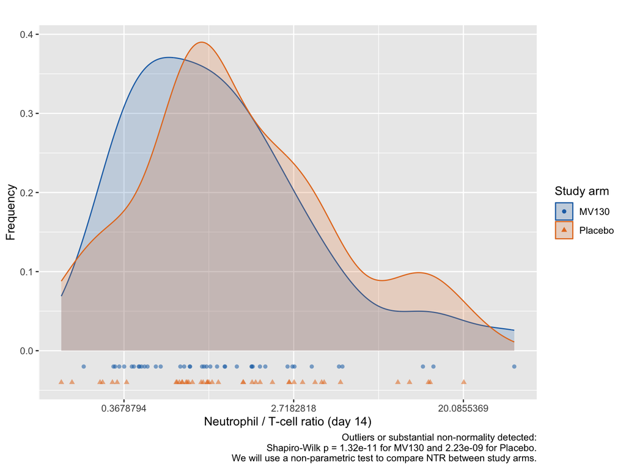

Figure 3: Visual inspection for severe non-normality of the NTR data at day 14 by study arm.

```r
normality_test <- mv130df_pp %>%
  dplyr::group_by(studyArm) %>%
  dplyr::summarise(
    normality_p_value = shapiro.test(ntrDay14)$p.value,
    .groups = "drop"
  )

# Plot NTR at Day 14 by intervention arm
ggplot(mv130df_pp, mapping=aes(x = ntrDay14, fill = studyArm)) +
  geom_density(mapping=aes(col=studyArm),position="dodge",alpha=0.2) +
  geom_point(mapping=aes(y=ifelse(studyArm=="MV130",-0.02,-0.04),alpha=0.5,col=studyArm,pch=studyArm)) +
  labs(
    title = "",
    x = "Neutrophil / T-cell ratio (day 14)",
    y = "Frequency",
    caption = ifelse(sum(normality_test$normality_p_value < 0.05)>0,
                       paste(sep="","Outliers or substantial non-normality detected:\nShapiro-Wilk p = ",signif(normality_test$normality_p_value[1],digits=3)," for ",normality_test$studyArm[1]," and ",signif(normality_test$normality_p_value[2],digits=3)," for ",normality_test$studyArm[2],".\nWe will use a non-parametric test to compare NTR between study arms."),
                       "No severe outliers or other substantial non-normality are obvious.\nThe use of a t-test for comparing NTR between study arms is appropriate.")
) +
  scale_fill_manual(values = c("MV130" = "#1f70b4", "Placebo" = "#e57a23"), name="Study arm") +
  scale_colour_manual(values = c("MV130" = "#1f70b4", "Placebo" = "#e57a23"), name="Study arm") +
  scale_shape_manual(values=16:17,name="Study arm") +
  scale_x_continuous(trans="log") +
  guides(alpha="none")
```

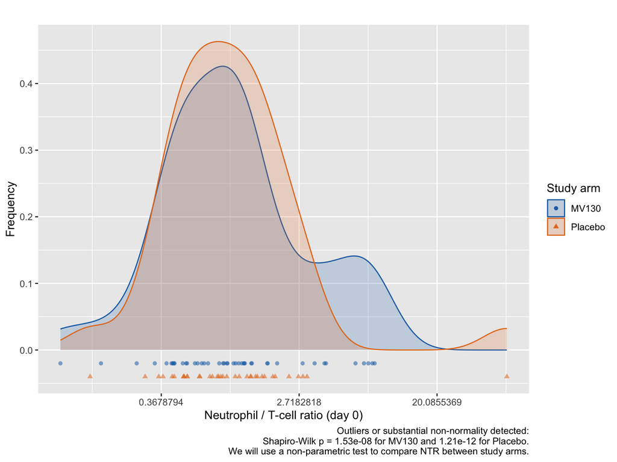

Figure 4: Visual inspection for severe non-normality of the NTR data at day 0 by study arm.

```r
normality_test <- mv130df_pp %>%
  dplyr::group_by(studyArm) %>%
  dplyr::summarise(
    normality_p_value = shapiro.test(ntrDay0)$p.value,
    .groups = "drop"
  )

# Plot NTR at Day 14 by intervention arm
ggplot(mv130df_pp, mapping=aes(x = ntrDay0, fill = studyArm)) +
  geom_density(mapping=aes(col=studyArm),position="dodge",alpha=0.2) +
  geom_point(mapping=aes(y=ifelse(studyArm=="MV130",-0.02,-0.04),alpha=0.5,col=studyArm,pch=studyArm)) +
  labs(
    title = "",
    x = "Neutrophil / T-cell ratio (day 0)",
    y = "Frequency",
    caption = ifelse(sum(normality_test$normality_p_value < 0.05)>0,
                       paste(sep="","Outliers or substantial non-normality detected:\nShapiro-Wilk p = ",signif(normality_test$normality_p_value[1],digits=3)," for ",normality_test$studyArm[1]," and ",signif(normality_test$normality_p_value[2],digits=3)," for ",normality_test$studyArm[2],".\nWe will use a non-parametric test to compare NTR between study arms."),
                       "No severe outliers or other substantial non-normality are obvious.\nThe use of a t-test for comparing NTR between study arms is appropriate.")
) +
  scale_fill_manual(values = c("MV130" = "#1f70b4", "Placebo" = "#e57a23"), name="Study arm") +
  scale_colour_manual(values = c("MV130" = "#1f70b4", "Placebo" = "#e57a23"), name="Study arm") +
  scale_shape_manual(values=16:17,name="Study arm") +
  scale_x_continuous(trans="log") +
  guides(alpha="none")
```

#### 10.5.1.2 Analysis

```r
mainAnaNTRDay14<-wilcox.test(ntrDay14~studyArm,data=mv130df_pp)

mainAnaNTRDay14table<-mv130df_pp %>%
  dplyr::group_by(studyArm) %>%
  dplyr::summarise(
    n=sum(!is.na(ntrDay14)),
    median=format(nsmall=3,round(digits=3,median(ntrDay14,na.rm=T))),
    Q25=format(nsmall=3,round(digits=3,quantile(ntrDay14,prob=0.25,na.rm=T))),
    Q75=format(nsmall=3,round(digits=3,quantile(ntrDay14,prob=0.75,na.rm=T)))
  ) %>%
  dplyr::mutate(
    IQR=paste(sep="","(",Q25,",",Q75,")")
  ) %>%
  dplyr::select(studyArm,n,median,IQR)

mainAnaNTRDay14table %>%
  knitr::kable(row.names=FALSE,col.names=c("Study arm","n","Median","IQR"),caption=paste(sep="","Wilcoxon rank-sum test comparing NTR at day 14 between study arms: p = ",format(nsmall=3,round(digits=3,mainAnaNTRDay14$p.value)))) %>%
  kableExtra::kable_styling(full_width = FALSE)
```

Table 6: Comparison of NTR at day 14 between study arms.

Wilcoxon rank-sum test comparing NTR at day 14 between study arms: p = 0.435

| Study arm | n | Median | IQR |
| --- | --- | --- | --- |
| MV130 | 40 | 0.959 | (0.465,1.857) |
| Placebo | 42 | 1.020 | (0.730,2.694) |

This is in line with day 0 NTR, which are also not statistically different between study arms.

```r
mainAnaNTRDay0<-wilcox.test(ntrDay0~studyArm,data=mv130df_pp)

mainAnaNTRDay0table<-mv130df_pp %>%
  dplyr::group_by(studyArm) %>%
  dplyr::summarise(
    n=sum(!is.na(ntrDay0)),
    median=format(nsmall=3,round(digits=3,median(ntrDay0,na.rm=T))),
    Q25=format(nsmall=3,round(digits=3,quantile(ntrDay0,prob=0.25,na.rm=T))),
    Q75=format(nsmall=3,round(digits=3,quantile(ntrDay0,prob=0.75,na.rm=T)))
  ) %>%
  dplyr::mutate(
    IQR=paste(sep="","(",Q25,",",Q75,")")
  ) %>%
  dplyr::select(studyArm,n,median,IQR)

mainAnaNTRDay0table %>%
  knitr::kable(row.names=FALSE,col.names=c("Study arm","n","Median","IQR"),caption=paste(sep="","Wilcoxon rank-sum test comparing NTR at day 0 between study arms: p = ",format(nsmall=3,round(digits=3,mainAnaNTRDay0$p.value)))) %>%
  kableExtra::kable_styling(full_width = FALSE)
```

Table 7: Comparison of NTR at day 0 between study arms.

Wilcoxon rank-sum test comparing NTR at day 0 between study arms: p = 0.829

| Study arm | n | Median | IQR |
| --- | --- | --- | --- |
| MV130 | 44 | 0.958 | (0.521,1.714) |
| Placebo | 36 | 0.886 | (0.530,1.509) |

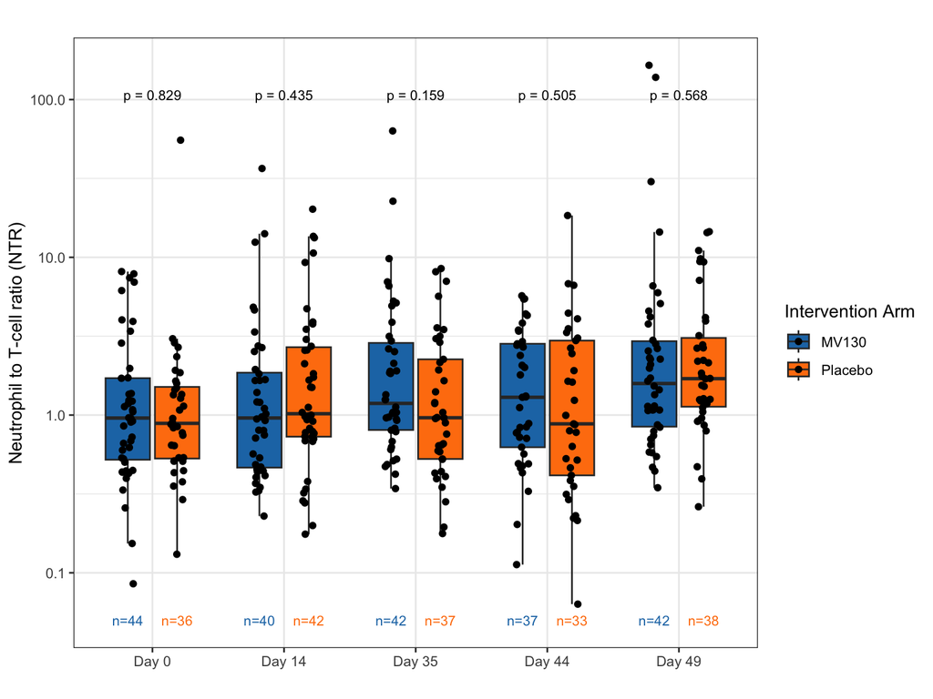

Figure 5: NTR at days 0, 14, 35, 44 and 49 by study arm. P-value at the top of each study visit are comparing NTR between study arms using a Wilcoxon’s rank-sum test.

```r
# Reshape data to long format
ntr_long <- mv130df_pp %>%
  dplyr::select(pid, carriage_6B, studyArm, ntrDay0, ntrDay14, ntrDay35, ntrDay44, ntrDay49) %>%
  pivot_longer(
    cols = c(ntrDay0, ntrDay14,  ntrDay35, ntrDay44, ntrDay49),
    names_to = "Day",
    values_to = "NTR"
  )

# Convert 'Day' to a factor
ntr_long$Day <- factor(ntr_long$Day, levels = c("ntrDay0", "ntrDay14", "ntrDay35", "ntrDay44", "ntrDay49"), labels = c("Day 0", "Day 14", "Day 35", "Day 44", "Day 49"))

nMat<-ntr_long %>%
  dplyr::group_by(Day,studyArm) %>%
  dplyr::summarise(n=sum(!is.na(NTR)),.groups="drop")

ggplot(ntr_long, aes(x = Day, y = NTR, fill = studyArm)) +
  geom_boxplot(outlier.shape = NA) +
  geom_point(position = position_jitterdodge(jitter.width = 0.2))+
  labs(
    title = "",
    x = "",
    y = "Neutrophil to T-cell ratio (NTR)",
    fill = "Intervention Arm"
  ) +
  scale_y_log10() +
  scale_fill_manual(values = c("MV130" = "#1f77b4", "Placebo" = "#ff7f0e")) +
  theme(
    plot.title = element_text(hjust = 0.5),
  )+
  stat_compare_means(method = "wilcox.test", aes(group=studyArm, label = ifelse(..p.. < 0.001, "p < 0.001", sprintf("p = %.3f", ..p..))), label.x = 1.5, label.y = 2, size = 3) +
  geom_text(data = nMat,mapping = aes(x = Day, y = 0.05, col = studyArm, group = studyArm, label = paste0("n=", n)), position = position_dodge(width = 0.75),size = 3) +
  scale_color_manual(values = c("MV130" = "#1f77b4", "Placebo" = "#ff7f0e"),guide="none") +
  theme_bw()
```

## 10.6 Secondary analyses

### 10.6.1 Sex-stratified

We repeat the analyses, but stratify by sex - as requested by a reviewer.

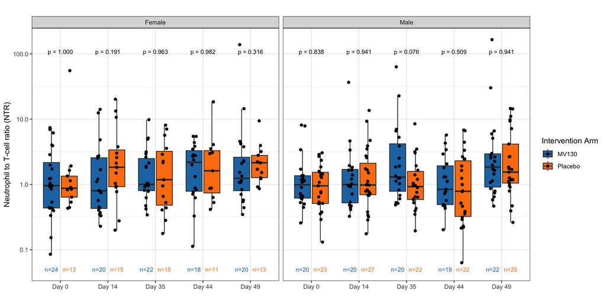

Figure 6: NTR at days 0, 14, 35, 44 and 49 by study arm and sex. P-value at the top of each study visit are comparing NTR between study arms using a Wilcoxon’s rank-sum test.

```r
# Reshape data to long format
ntr_long <- mv130df_pp %>%
  dplyr::select(pid, sex, carriage_6B, studyArm, ntrDay0, ntrDay14, ntrDay35, ntrDay44, ntrDay49) %>%
  pivot_longer(
    cols = c(ntrDay0, ntrDay14,  ntrDay35, ntrDay44, ntrDay49),
    names_to = "Day",
    values_to = "NTR"
  )

# Convert 'Day' to a factor
ntr_long$Day <- factor(ntr_long$Day, levels = c("ntrDay0", "ntrDay14", "ntrDay35", "ntrDay44", "ntrDay49"), labels = c("Day 0", "Day 14", "Day 35", "Day 44", "Day 49"))

nMat<-ntr_long %>%
  dplyr::group_by(sex, Day,studyArm) %>%
  dplyr::summarise(n=sum(!is.na(NTR)),.groups="drop")

ggplot(ntr_long, aes(x = Day, y = NTR, fill = studyArm)) +
  geom_boxplot(outlier.shape = NA) +
  geom_point(position = position_jitterdodge(jitter.width = 0.2))+
  labs(
    title = "",
    x = "",
    y = "Neutrophil to T-cell ratio (NTR)",
    fill = "Intervention Arm"
  ) +
  scale_y_log10() +
  scale_fill_manual(values = c("MV130" = "#1f77b4", "Placebo" = "#ff7f0e")) +
  theme(
    plot.title = element_text(hjust = 0.5),
  )+
  stat_compare_means(method = "wilcox.test", aes(group=studyArm, label = ifelse(..p.. < 0.001, "p < 0.001", sprintf("p = %.3f", ..p..))), label.x = 1.5, label.y = 2, size = 3) +
  geom_text(data = nMat,mapping = aes(x = Day, y = 0.05, col = studyArm, group = studyArm, label = paste0("n=", n)), position = position_dodge(width = 0.75),size = 3) +
  scale_color_manual(values = c("MV130" = "#1f77b4", "Placebo" = "#ff7f0e"),guide="none") +
  facet_wrap(~sex) +
  theme_bw()
```

### 10.6.2 Besides NTR, plots for cell proportions, absolute cell counts and ratios to epithelial cells

As per reviewer comment, we also generate these figures with 1) cell proportions on Figure 7 and Figure 8, 2) absolute numbers on Figure 9 and Figure 10, 3) neutrophil-to-epithelial cell ratios and T-cell-to-epithelial cell ratios on Figure 11 and Figure 12.

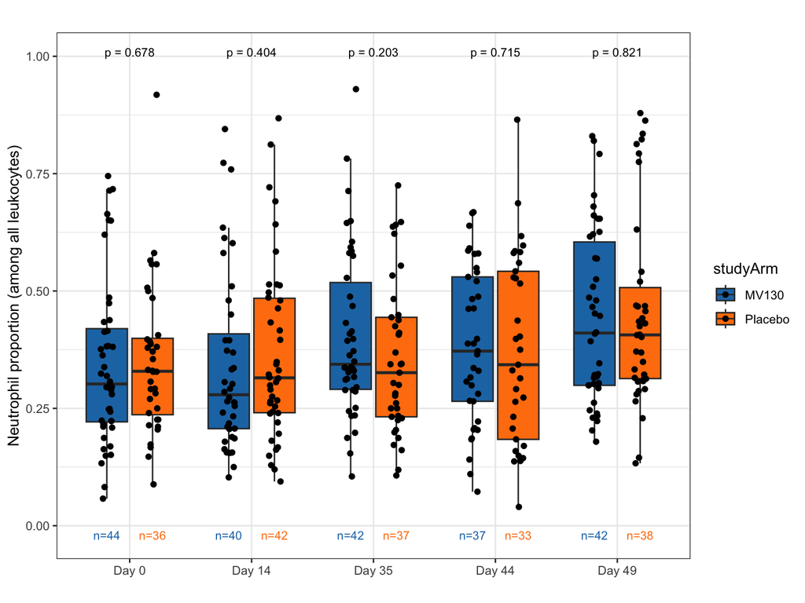

Figure 7: Neutrophil proportions at days 0, 14, 35, 44 and 49 by study arm. P-value at the top of each study visit are comparing proportions between study arms using Wilcoxon’s rank-sum test.

```r
# Reshape data to long format
ntr_long <- mv130df_pp %>%
  dplyr::select(pid, carriage_6B, studyArm, neutroPropDay0, neutroPropDay14, neutroPropDay35, neutroPropDay44, neutroPropDay49) %>%
  pivot_longer(
    cols = c(neutroPropDay0, neutroPropDay14,  neutroPropDay35, neutroPropDay44, neutroPropDay49),
    names_to = "Day",
    values_to = "neutroProp"
  )

# Convert 'Day' to a factor
ntr_long$Day <- factor(ntr_long$Day, levels = c("neutroPropDay0", "neutroPropDay14", "neutroPropDay35", "neutroPropDay44", "neutroPropDay49"), labels = c("Day 0", "Day 14", "Day 35", "Day 44", "Day 49"))

nMat<-ntr_long %>%
  dplyr::group_by(Day,studyArm) %>%
  dplyr::summarise(n=sum(!is.na(neutroProp)),.groups="drop")

ggplot(ntr_long, aes(x = Day, y = neutroProp/100, fill = studyArm)) +
  geom_boxplot(outlier.shape = NA) +
  geom_point(position = position_jitterdodge(jitter.width = 0.2))+
  labs(
    title = "",
    x = "",
    y = "Neutrophil proportion (among all leukocytes)",
    color = "Intervention Arm"
  ) +
  scale_fill_manual(values = c("MV130" = "#1f77b4", "Placebo" = "#ff7f0e")) +
  theme(
    plot.title = element_text(hjust = 0.5),
  )+
  stat_compare_means(method = "wilcox.test", aes(group=studyArm, label = ifelse(..p.. < 0.001, "p < 0.001", sprintf("p = %.3f", ..p..))), label.x = 1.5, label.y = 1, size = 3) +
  geom_text(data = nMat,mapping = aes(x = Day, y = -0.02, col = studyArm, group = studyArm, label = paste0("n=", n)), position = position_dodge(width = 0.75),size = 3) +
  scale_color_manual(values = c("MV130" = "#1f77b4", "Placebo" = "#ff7f0e"),guide="none") +
  theme_bw()
```

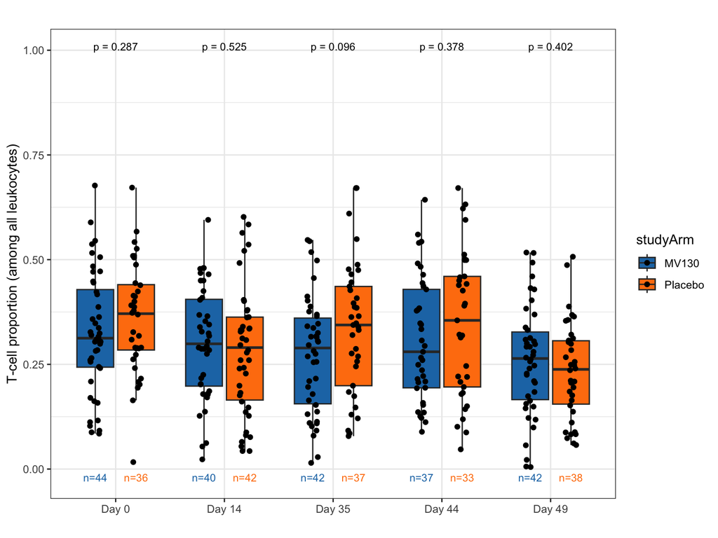

Figure 8: T-cell proportions at days 0, 14, 35, 44 and 49 by study arm. P-value at the top of each study visit are comparing proportions between study arms using Wilcoxon’s rank-sum test.

```r
# Reshape data to long format
ntr_long <- mv130df_pp %>%
  dplyr::select(pid, carriage_6B, studyArm, tcellPropDay0, tcellPropDay14, tcellPropDay35, tcellPropDay44, tcellPropDay49) %>%
  pivot_longer(
    cols = c(tcellPropDay0, tcellPropDay14,  tcellPropDay35, tcellPropDay44, tcellPropDay49),
    names_to = "Day",
    values_to = "tcellProp"
  )

# Convert 'Day' to a factor
ntr_long$Day <- factor(ntr_long$Day, levels = c("tcellPropDay0", "tcellPropDay14", "tcellPropDay35", "tcellPropDay44", "tcellPropDay49"), labels = c("Day 0", "Day 14", "Day 35", "Day 44", "Day 49"))

nMat<-ntr_long %>%
  dplyr::group_by(Day,studyArm) %>%
  dplyr::summarise(n=sum(!is.na(tcellProp)),.groups="drop")

ggplot(ntr_long, aes(x = Day, y = tcellProp/100, fill = studyArm)) +
  geom_boxplot(outlier.shape = NA) +
  geom_point(position = position_jitterdodge(jitter.width = 0.2))+
  labs(
    title = "",
    x = "",
    y = "T-cell proportion (among all leukocytes)",
    color = "Intervention Arm"
  ) +
  scale_fill_manual(values = c("MV130" = "#1f77b4", "Placebo" = "#ff7f0e")) +
  theme(
    plot.title = element_text(hjust = 0.5),
  )+
  stat_compare_means(method = "wilcox.test", aes(group=studyArm, label = ifelse(..p.. < 0.001, "p < 0.001", sprintf("p = %.3f", ..p..))), label.x = 1.5, label.y = 1, size = 3) +
  geom_text(data = nMat,mapping = aes(x = Day, y = -0.02, col = studyArm, group = studyArm, label = paste0("n=", n)), position = position_dodge(width = 0.75),size = 3) +
  scale_color_manual(values = c("MV130" = "#1f77b4", "Placebo" = "#ff7f0e"),guide="none") +
  theme_bw()
```

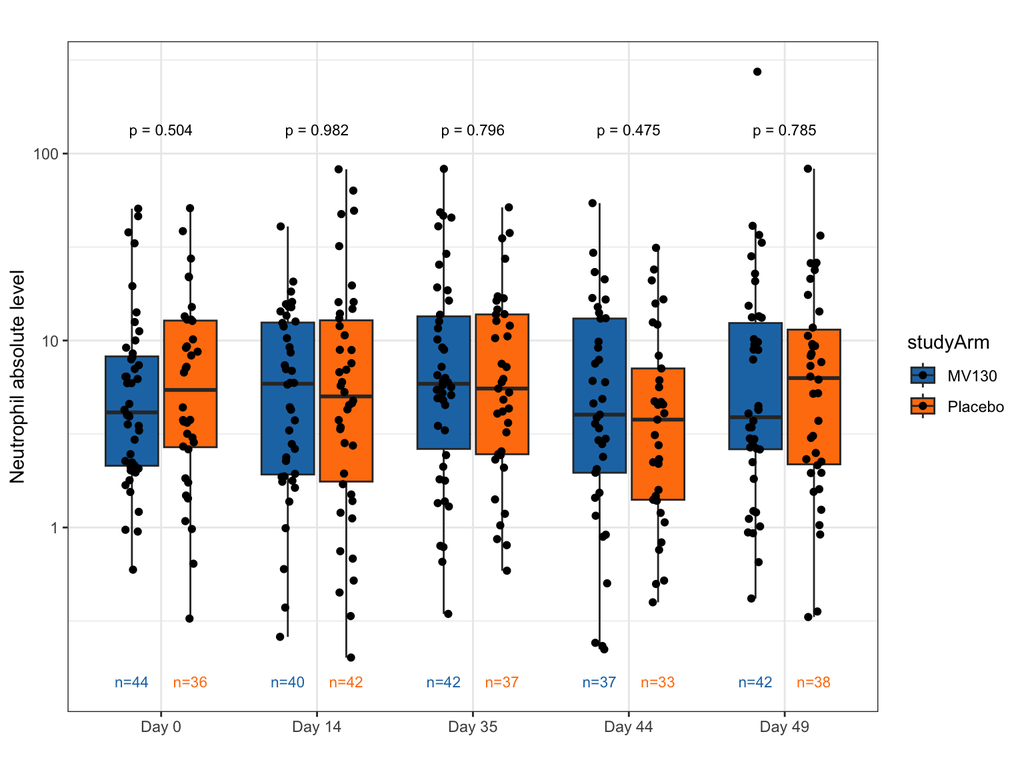

Figure 9: Neutrophil absolute levels at days 0, 14, 35, 44 and 49 by study arm. P-value at the top of each study visit are comparing levels between study arms using Wilcoxon’s rank-sum test.

```r
# Reshape data to long format
ntr_long <- mv130df_pp %>%
  dplyr::select(pid, carriage_6B, studyArm, neutroAbsDay0, neutroAbsDay14, neutroAbsDay35, neutroAbsDay44, neutroAbsDay49) %>%
  pivot_longer(
    cols = c(neutroAbsDay0, neutroAbsDay14,  neutroAbsDay35, neutroAbsDay44, neutroAbsDay49),
    names_to = "Day",
    values_to = "neutroAbs"
  )

# Convert 'Day' to a factor
ntr_long$Day <- factor(ntr_long$Day, levels = c("neutroAbsDay0", "neutroAbsDay14", "neutroAbsDay35", "neutroAbsDay44", "neutroAbsDay49"), labels = c("Day 0", "Day 14", "Day 35", "Day 44", "Day 49"))

nMat<-ntr_long %>%
  dplyr::group_by(Day,studyArm) %>%
  dplyr::summarise(n=sum(!is.na(neutroAbs)),.groups="drop")

ggplot(ntr_long, aes(x = Day, y = neutroAbs, fill = studyArm)) +
  geom_boxplot(outlier.shape = NA) +
  geom_point(position = position_jitterdodge(jitter.width = 0.2))+
  labs(
    title = "",
    x = "",
    y = "Neutrophil absolute level",
    color = "Intervention Arm"
  ) +
  scale_fill_manual(values = c("MV130" = "#1f77b4", "Placebo" = "#ff7f0e")) +
  scale_y_log10() +
  theme(
    plot.title = element_text(hjust = 0.5),
  )+
  stat_compare_means(method = "wilcox.test", aes(group=studyArm, label = ifelse(..p.. < 0.001, "p < 0.001", sprintf("p = %.3f", ..p..))), label.x = 1.5, label.y = 2.1, size = 3) +
  geom_text(data = nMat,mapping = aes(x = Day, y = 0.15, col = studyArm, group = studyArm, label = paste0("n=", n)), position = position_dodge(width = 0.75),size = 3) +
  scale_color_manual(values = c("MV130" = "#1f77b4", "Placebo" = "#ff7f0e"),guide="none") +
  theme_bw()
```

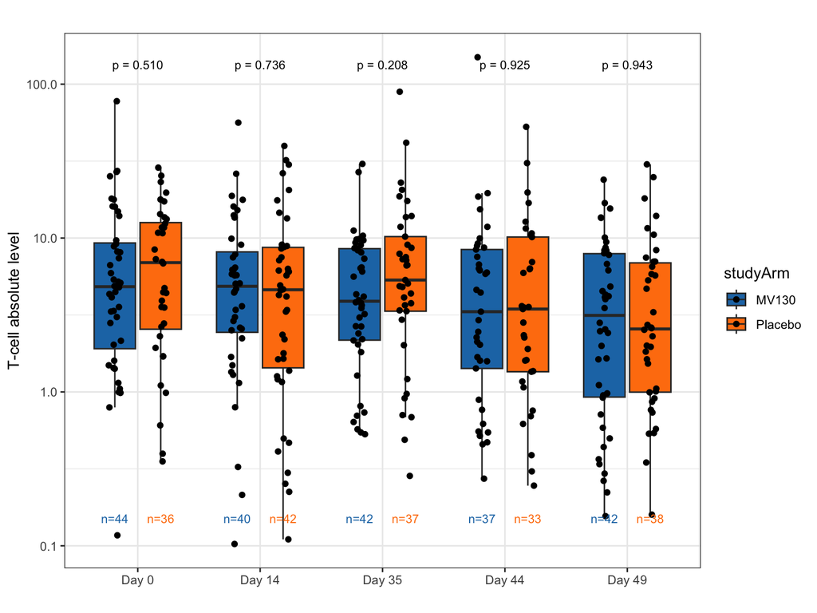

Figure 10: T-cell absolute levels at days 0, 14, 35, 44 and 49 by study arm. P-value at the top of each study visit are comparing levels between study arms using Wilcoxon’s rank-sum test.

```r
# Reshape data to long format
ntr_long <- mv130df_pp %>%
  dplyr::select(pid, carriage_6B, studyArm, tcellAbsDay0, tcellAbsDay14, tcellAbsDay35, tcellAbsDay44, tcellAbsDay49) %>%
  pivot_longer(
    cols = c(tcellAbsDay0, tcellAbsDay14,  tcellAbsDay35, tcellAbsDay44, tcellAbsDay49),
    names_to = "Day",
    values_to = "tcellAbs"
  )

# Convert 'Day' to a factor
ntr_long$Day <- factor(ntr_long$Day, levels = c("tcellAbsDay0", "tcellAbsDay14", "tcellAbsDay35", "tcellAbsDay44", "tcellAbsDay49"), labels = c("Day 0", "Day 14", "Day 35", "Day 44", "Day 49"))

nMat<-ntr_long %>%
  dplyr::group_by(Day,studyArm) %>%
  dplyr::summarise(n=sum(!is.na(tcellAbs)),.groups="drop")

ggplot(ntr_long, aes(x = Day, y = tcellAbs, fill = studyArm)) +
  geom_boxplot(outlier.shape = NA) +
  geom_point(position = position_jitterdodge(jitter.width = 0.2))+
  labs(
    title = "",
    x = "",
    y = "T-cell absolute level",
    color = "Intervention Arm"
  ) +
  scale_fill_manual(values = c("MV130" = "#1f77b4", "Placebo" = "#ff7f0e")) +
  scale_y_log10() +
  theme(
    plot.title = element_text(hjust = 0.5),
  )+
  stat_compare_means(method = "wilcox.test", aes(group=studyArm, label = ifelse(..p.. < 0.001, "p < 0.001", sprintf("p = %.3f", ..p..))), label.x = 1.5, label.y = 2.1, size = 3) +
  geom_text(data = nMat,mapping = aes(x = Day, y = 0.15, col = studyArm, group = studyArm, label = paste0("n=", n)), position = position_dodge(width = 0.75),size = 3) +
  scale_color_manual(values = c("MV130" = "#1f77b4", "Placebo" = "#ff7f0e"),guide="none") +
  theme_bw()
```

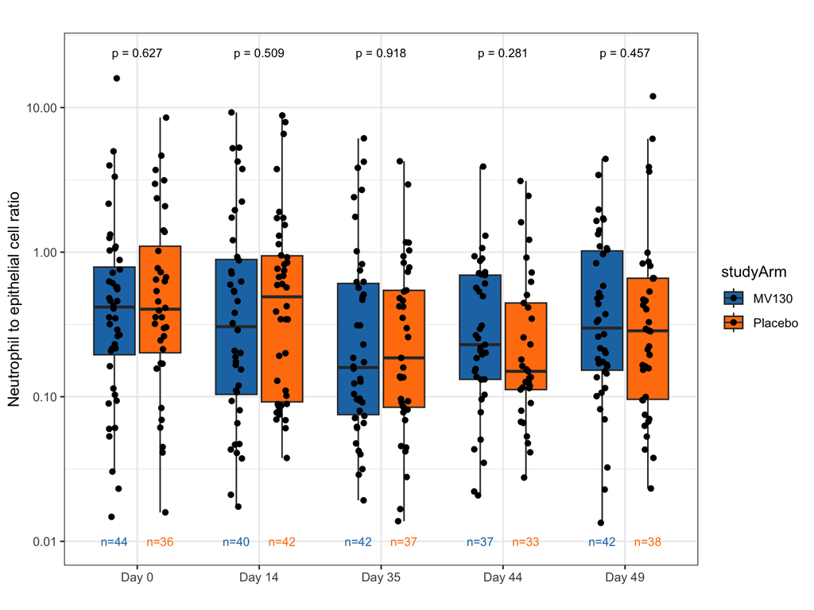

Figure 11: Neutrophil to epithelial cell ratios at days 0, 14, 35, 44 and 49 by study arm. P-value at the top of each study visit are comparing ratios between study arms using Wilcoxon’s rank-sum test.

```r
# Reshape data to long format
ntr_long <- mv130df_pp %>%
  dplyr::select(pid, carriage_6B, studyArm, neutroEpithRatioDay0, neutroEpithRatioDay14, neutroEpithRatioDay35, neutroEpithRatioDay44, neutroEpithRatioDay49) %>%
  pivot_longer(
    cols = c(neutroEpithRatioDay0, neutroEpithRatioDay14,  neutroEpithRatioDay35, neutroEpithRatioDay44, neutroEpithRatioDay49),
    names_to = "Day",
    values_to = "neutroEpithRatio"
  )

# Convert 'Day' to a factor
ntr_long$Day <- factor(ntr_long$Day, levels = c("neutroEpithRatioDay0", "neutroEpithRatioDay14", "neutroEpithRatioDay35", "neutroEpithRatioDay44", "neutroEpithRatioDay49"), labels = c("Day 0", "Day 14", "Day 35", "Day 44", "Day 49"))

nMat<-ntr_long %>%
  dplyr::group_by(Day,studyArm) %>%
  dplyr::summarise(n=sum(!is.na(neutroEpithRatio)),.groups="drop")

ggplot(ntr_long, aes(x = Day, y = neutroEpithRatio, fill = studyArm)) +
  geom_boxplot(outlier.shape = NA) +
  geom_point(position = position_jitterdodge(jitter.width = 0.2))+
  labs(
    title = "",
    x = "",
    y = "Neutrophil to epithelial cell ratio",
    color = "Intervention Arm"
  ) +
  scale_y_log10() +
  scale_fill_manual(values = c("MV130" = "#1f77b4", "Placebo" = "#ff7f0e")) +
  theme(
    plot.title = element_text(hjust = 0.5),
  )+
  stat_compare_means(method = "wilcox.test", aes(group=studyArm, label = ifelse(..p.. < 0.001, "p < 0.001", sprintf("p = %.3f", ..p..))), label.x = 1.5, label.y = 1.35, size = 3) +
  geom_text(data = nMat,mapping = aes(x = Day, y = 0.01, col = studyArm, group = studyArm, label = paste0("n=", n)), position = position_dodge(width = 0.75),size = 3) +
  scale_color_manual(values = c("MV130" = "#1f77b4", "Placebo" = "#ff7f0e"),guide="none") +
  theme_bw()
```

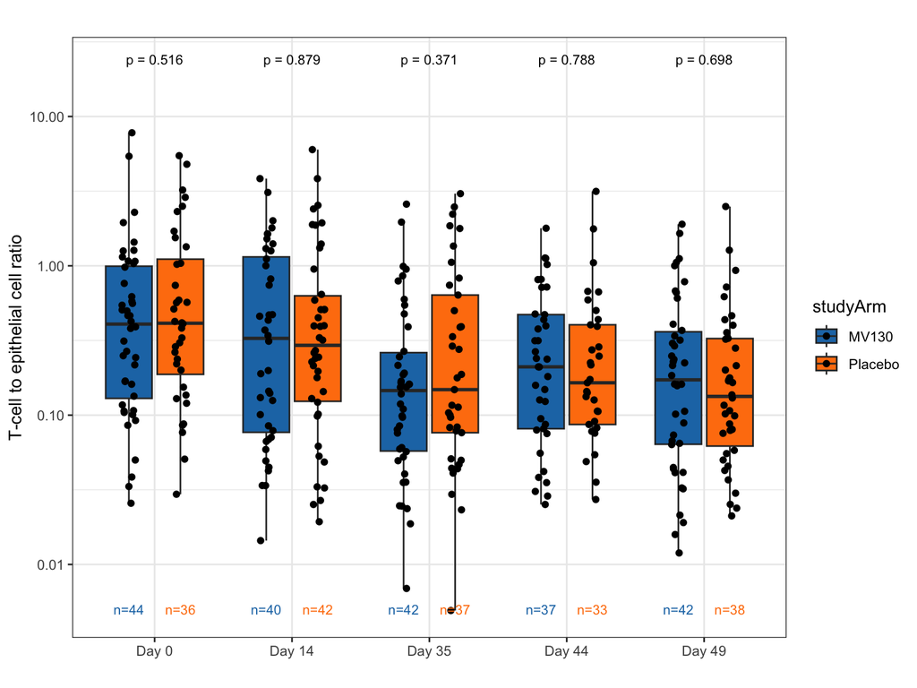

Figure 12: T-cell to epithelial cell ratios at days 0, 14, 35, 44 and 49 by study arm. P-value at the top of each study visit are comparing ratios between study arms using Wilcoxon’s rank-sum test.

```r
# Reshape data to long format
ntr_long <- mv130df_pp %>%
  dplyr::select(pid, carriage_6B, studyArm, tcellEpithRatioDay0, tcellEpithRatioDay14, tcellEpithRatioDay35, tcellEpithRatioDay44, tcellEpithRatioDay49) %>%
  pivot_longer(
    cols = c(tcellEpithRatioDay0, tcellEpithRatioDay14,  tcellEpithRatioDay35, tcellEpithRatioDay44, tcellEpithRatioDay49),
    names_to = "Day",
    values_to = "tcellEpithRatio"
  )

# Convert 'Day' to a factor
ntr_long$Day <- factor(ntr_long$Day, levels = c("tcellEpithRatioDay0", "tcellEpithRatioDay14", "tcellEpithRatioDay35", "tcellEpithRatioDay44", "tcellEpithRatioDay49"), labels = c("Day 0", "Day 14", "Day 35", "Day 44", "Day 49"))

nMat<-ntr_long %>%
  dplyr::group_by(Day,studyArm) %>%
  dplyr::summarise(n=sum(!is.na(tcellEpithRatio)),.groups="drop")

ggplot(ntr_long, aes(x = Day, y = tcellEpithRatio, fill = studyArm)) +
  geom_boxplot(outlier.shape = NA) +
  geom_point(position = position_jitterdodge(jitter.width = 0.2))+
  labs(
    title = "",
    x = "",
    y = "T-cell to epithelial cell ratio",
    color = "Intervention Arm"
  ) +
  scale_y_log10() +
  scale_fill_manual(values = c("MV130" = "#1f77b4", "Placebo" = "#ff7f0e")) +
  theme(
    plot.title = element_text(hjust = 0.5),
  )+
  stat_compare_means(method = "wilcox.test", aes(group=studyArm, label = ifelse(..p.. < 0.001, "p < 0.001", sprintf("p = %.3f", ..p..))), label.x = 1.5, label.y = 1.35, size = 3) +
  geom_text(data = nMat,mapping = aes(x = Day, y = 0.005, col = studyArm, group = studyArm, label = paste0("n=", n)), position = position_dodge(width = 0.75),size = 3) +
  scale_color_manual(values = c("MV130" = "#1f77b4", "Placebo" = "#ff7f0e"),guide="none") +
  theme_bw()
```

### 10.6.3 Day 35 NTR comparison

#### 10.6.3.1 Checking for non-normality

As already mentioned, the day 35 NTR data are also not normally distributed (Figure 13).

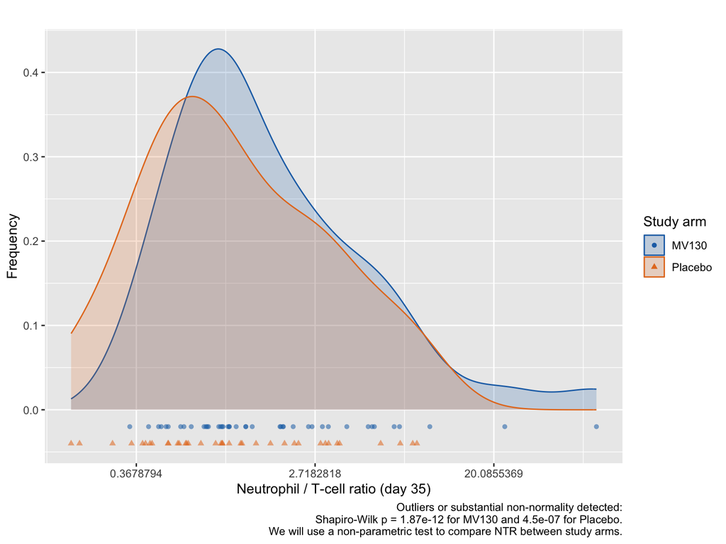

Figure 13: Visual inspection for severe non-normality of the NTR data at day 35 by study arm.

```r
normality_test <- mv130df_pp %>%
  dplyr::group_by(studyArm) %>%
  dplyr::summarise(
    normality_p_value = shapiro.test(ntrDay35)$p.value,
    .groups = "drop"
  )

# Plot NTR at Day 14 by intervention arm
ggplot(mv130df_pp, mapping=aes(x = ntrDay35, fill = studyArm)) +
  geom_density(mapping=aes(col=studyArm),position="dodge",alpha=0.2) +
  geom_point(mapping=aes(y=ifelse(studyArm=="MV130",-0.02,-0.04),alpha=0.5,col=studyArm,pch=studyArm)) +
  labs(
    title = "",
    x = "Neutrophil / T-cell ratio (day 35)",
    y = "Frequency",
    caption = ifelse(sum(normality_test$normality_p_value < 0.05)>0,
                       paste(sep="","Outliers or substantial non-normality detected:\nShapiro-Wilk p = ",signif(normality_test$normality_p_value[1],digits=3)," for ",normality_test$studyArm[1]," and ",signif(normality_test$normality_p_value[2],digits=3)," for ",normality_test$studyArm[2],".\nWe will use a non-parametric test to compare NTR between study arms."),
                       "No severe outliers or other substantial non-normality are obvious.\nThe use of a t-test for comparing NTR between study arms is appropriate.")
) +
  scale_fill_manual(values = c("MV130" = "#1f70b4", "Placebo" = "#e57a23"), name="Study arm") +
  scale_colour_manual(values = c("MV130" = "#1f70b4", "Placebo" = "#e57a23"), name="Study arm") +
  scale_shape_manual(values=16:17,name="Study arm") +
  scale_x_continuous(trans="log") +
  guides(alpha="none")
```

#### 10.6.3.2 Analysis

The NTR distributions are not statistically different between study arms.

```r
mainAnaNTRDay35<-wilcox.test(ntrDay35~studyArm,data=mv130df_pp)

mainAnaNTRDay35table<-mv130df_pp %>%
  dplyr::group_by(studyArm) %>%
  dplyr::summarise(
    n=sum(!is.na(ntrDay35)),
    median=format(nsmall=3,round(digits=3,median(ntrDay35,na.rm=T))),
    Q25=format(nsmall=3,round(digits=3,quantile(ntrDay35,prob=0.25,na.rm=T))),
    Q75=format(nsmall=3,round(digits=3,quantile(ntrDay35,prob=0.75,na.rm=T)))
  ) %>%
  dplyr::mutate(
    IQR=paste(sep="","(",Q25,",",Q75,")")
  ) %>%
  dplyr::select(studyArm,n,median,IQR)

mainAnaNTRDay35table %>%
  knitr::kable(row.names=FALSE,col.names=c("Study arm","n","Median","IQR"),caption=paste(sep="","Wilcoxon rank-sum test comparing NTR at day 35 between study arms: p = ",format(nsmall=3,round(digits=3,mainAnaNTRDay35$p.value)))) %>%
  kableExtra::kable_styling(full_width = FALSE)
```

Table 8: Comparison of NTR at day 35 between study arms.

Wilcoxon rank-sum test comparing NTR at day 35 between study arms: p = 0.159

| Study arm | n | Median | IQR |
| --- | --- | --- | --- |
| MV130 | 42 | 1.187 | (0.804,2.869) |
| Placebo | 37 | 0.962 | (0.527,2.256) |

### 10.6.4 NTR response by carriage status

We compare NTR at days 0, 14, 35, 44 and 49 between carriage groups. NTR at days 0 and 14 is probably not very meaningful however, given these time points were before carriage assessment.

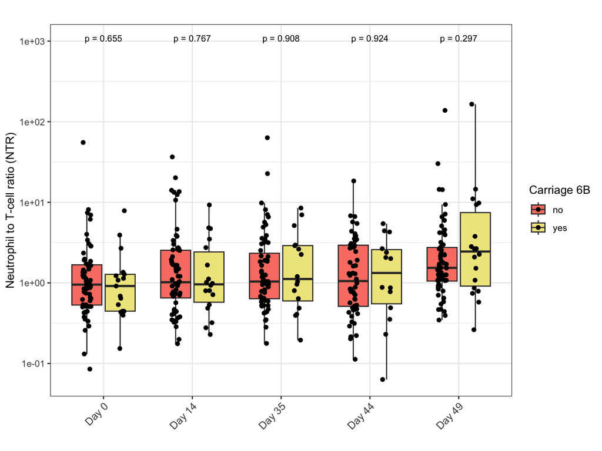

Figure 14: Comparison of day 0, 14, 35, 44 and 49 NTR between experimental carriage groups.

```r
# Reshape data to long format
ntr_long <- mv130df_pp %>%
  dplyr::select(pid, carriage_6B, studyArm, ntrDay0, ntrDay14, ntrDay35, ntrDay44, ntrDay49) %>%
  pivot_longer(
    cols = c(ntrDay0, ntrDay14, ntrDay35, ntrDay44, ntrDay49),
    names_to = "Day",
    values_to = "NTR"
  )

# Convert 'Day' to a factor
ntr_long$Day <- factor(ntr_long$Day, levels = c("ntrDay0", "ntrDay14", "ntrDay35", "ntrDay44", "ntrDay49"), labels = c("Day 0", "Day 14", "Day 35", "Day 44", "Day 49"))


ggplot(ntr_long, aes(x = Day, y = NTR, fill = carriage_6B)) +
  geom_boxplot(outlier.shape = NA) +
  geom_point(position = position_jitterdodge(jitter.width = 0.2))+
  labs(
    title = "",
    x = "",
    y = "Neutrophil to T-cell ratio (NTR)",
    color = "6B carriage"
  ) +
  theme_bw() +
  theme(axis.text.x = element_text(angle = 45, hjust = 1, size = 10)) +
  scale_y_log10() +
  scale_fill_manual(values = c("yes" = "khaki", "no" = "salmon"), name="Carriage 6B") +
  theme(
    plot.title = element_text(hjust = 0.5),
  )+
  stat_compare_means(method = "wilcox.test", aes(group=carriage_6B, label = ifelse(..p.. < 0.001, "p < 0.001", sprintf("p = %.3f", ..p..))), label.x = 1.5, label.y = 3.0, size = 3)
```

#### 10.6.4.1 Cell proportions, absolute levels, and ratios to epithelial cells by carriage status

As requested by a reviewer we repeat the previous graph for other metrics: cell proportions on Figure 15 and Figure 16, cell absolute levels on Figure 17 and Figure 18 and ratios to epithelial cells on Figure 19 and Figure 20.

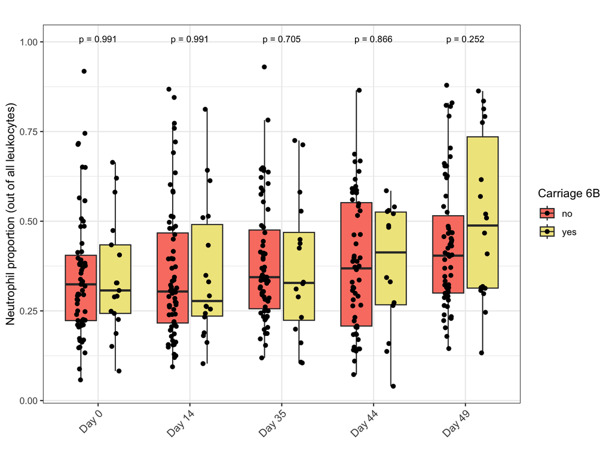

Figure 15: Comparison of day 0, 14, 35, 44 and 49 neutrophil proportions (out of all leukocytes) between experimental carriage groups.

```r
# Reshape data to long format
ntr_long <- mv130df_pp %>%
  dplyr::select(pid, carriage_6B, studyArm, neutroPropDay0, neutroPropDay14, neutroPropDay35, neutroPropDay44, neutroPropDay49) %>%
  pivot_longer(
    cols = c(neutroPropDay0, neutroPropDay14, neutroPropDay35, neutroPropDay44, neutroPropDay49),
    names_to = "Day",
    values_to = "neutroProp"
  )

# Convert 'Day' to a factor
ntr_long$Day <- factor(ntr_long$Day, levels = c("neutroPropDay0", "neutroPropDay14", "neutroPropDay35", "neutroPropDay44", "neutroPropDay49"), labels = c("Day 0", "Day 14", "Day 35", "Day 44", "Day 49"))


ggplot(ntr_long, aes(x = Day, y = neutroProp/100, fill = carriage_6B)) +
  geom_boxplot(outlier.shape = NA) +
  geom_point(position = position_jitterdodge(jitter.width = 0.2))+
  labs(
    title = "",
    x = "",
    y = "Neutrophil proportion (out of all leukocytes)",
    color = "6B carriage"
  ) +
  theme_bw() +
  theme(axis.text.x = element_text(angle = 45, hjust = 1, size = 10)) +
  scale_fill_manual(values = c("yes" = "khaki", "no" = "salmon"), name="Carriage 6B") +
  theme(
    plot.title = element_text(hjust = 0.5),
  )+
  stat_compare_means(method = "wilcox.test", aes(group=carriage_6B, label = ifelse(..p.. < 0.001, "p < 0.001", sprintf("p = %.3f", ..p..))), label.x = 1.5, label.y = 1, size = 3)
```

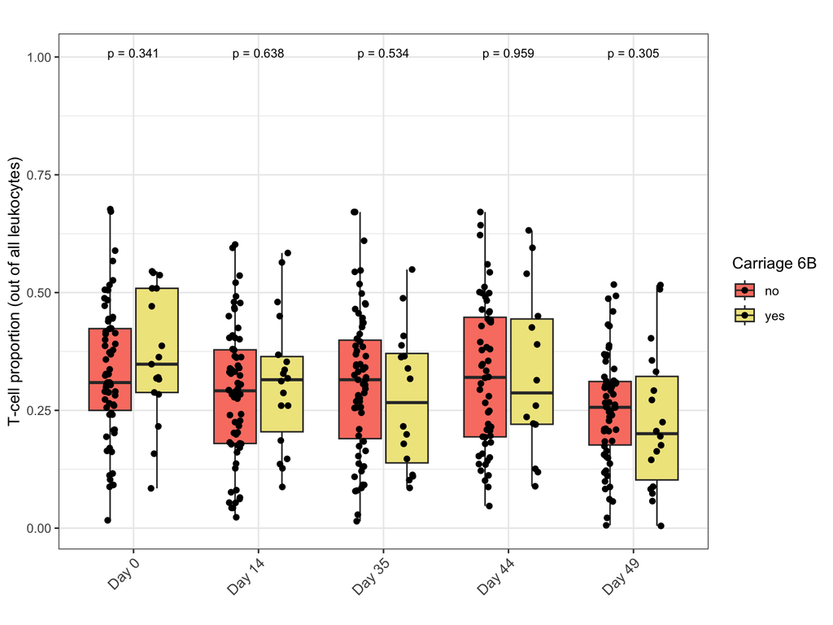

Figure 16: Comparison of day 0, 14, 35, 44 and 49 T-cell proportions (out of all leukocytes) between experimental carriage groups.

```r
# Reshape data to long format
ntr_long <- mv130df_pp %>%
  dplyr::select(pid, carriage_6B, studyArm, tcellPropDay0, tcellPropDay14, tcellPropDay35, tcellPropDay44, tcellPropDay49) %>%
  pivot_longer(
    cols = c(tcellPropDay0, tcellPropDay14, tcellPropDay35, tcellPropDay44, tcellPropDay49),
    names_to = "Day",
    values_to = "tcellProp"
  )

# Convert 'Day' to a factor
ntr_long$Day <- factor(ntr_long$Day, levels = c("tcellPropDay0", "tcellPropDay14", "tcellPropDay35", "tcellPropDay44", "tcellPropDay49"), labels = c("Day 0", "Day 14", "Day 35", "Day 44", "Day 49"))


ggplot(ntr_long, aes(x = Day, y = tcellProp/100, fill = carriage_6B)) +
  geom_boxplot(outlier.shape = NA) +
  geom_point(position = position_jitterdodge(jitter.width = 0.2))+
  labs(
    title = "",
    x = "",
    y = "T-cell proportion (out of all leukocytes)",
    color = "6B carriage"
  ) +
  theme_bw() +
  theme(axis.text.x = element_text(angle = 45, hjust = 1, size = 10)) +
  scale_fill_manual(values = c("yes" = "khaki", "no" = "salmon"), name="Carriage 6B") +
  theme(
    plot.title = element_text(hjust = 0.5),
  )+
  stat_compare_means(method = "wilcox.test", aes(group=carriage_6B, label = ifelse(..p.. < 0.001, "p < 0.001", sprintf("p = %.3f", ..p..))), label.x = 1.5, label.y = 1, size = 3)
```

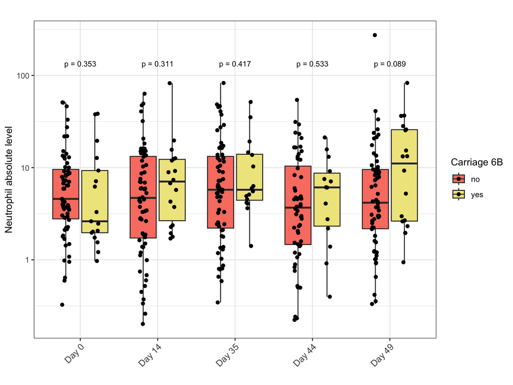

Figure 17: Comparison of day 0, 14, 35, 44 and 49 neutrophil absolute levels between experimental carriage groups.

```r
# Reshape data to long format
ntr_long <- mv130df_pp %>%
  dplyr::select(pid, carriage_6B, studyArm, neutroAbsDay0, neutroAbsDay14, neutroAbsDay35, neutroAbsDay44, neutroAbsDay49) %>%
  pivot_longer(
    cols = c(neutroAbsDay0, neutroAbsDay14, neutroAbsDay35, neutroAbsDay44, neutroAbsDay49),
    names_to = "Day",
    values_to = "neutroAbs"
  )

# Convert 'Day' to a factor
ntr_long$Day <- factor(ntr_long$Day, levels = c("neutroAbsDay0", "neutroAbsDay14", "neutroAbsDay35", "neutroAbsDay44", "neutroAbsDay49"), labels = c("Day 0", "Day 14", "Day 35", "Day 44", "Day 49"))


ggplot(ntr_long, aes(x = Day, y = neutroAbs, fill = carriage_6B)) +
  geom_boxplot(outlier.shape = NA) +
  geom_point(position = position_jitterdodge(jitter.width = 0.2))+
  labs(
    title = "",
    x = "",
    y = "Neutrophil absolute level",
    color = "6B carriage"
  ) +
  theme_bw() +
  theme(axis.text.x = element_text(angle = 45, hjust = 1, size = 10)) +
  scale_y_log10() +
  scale_fill_manual(values = c("yes" = "khaki", "no" = "salmon"), name="Carriage 6B") +
  theme(
    plot.title = element_text(hjust = 0.5),
  )+
  stat_compare_means(method = "wilcox.test", aes(group=carriage_6B, label = ifelse(..p.. < 0.001, "p < 0.001", sprintf("p = %.3f", ..p..))), label.x = 1.5, label.y = 2.1, size = 3)
```

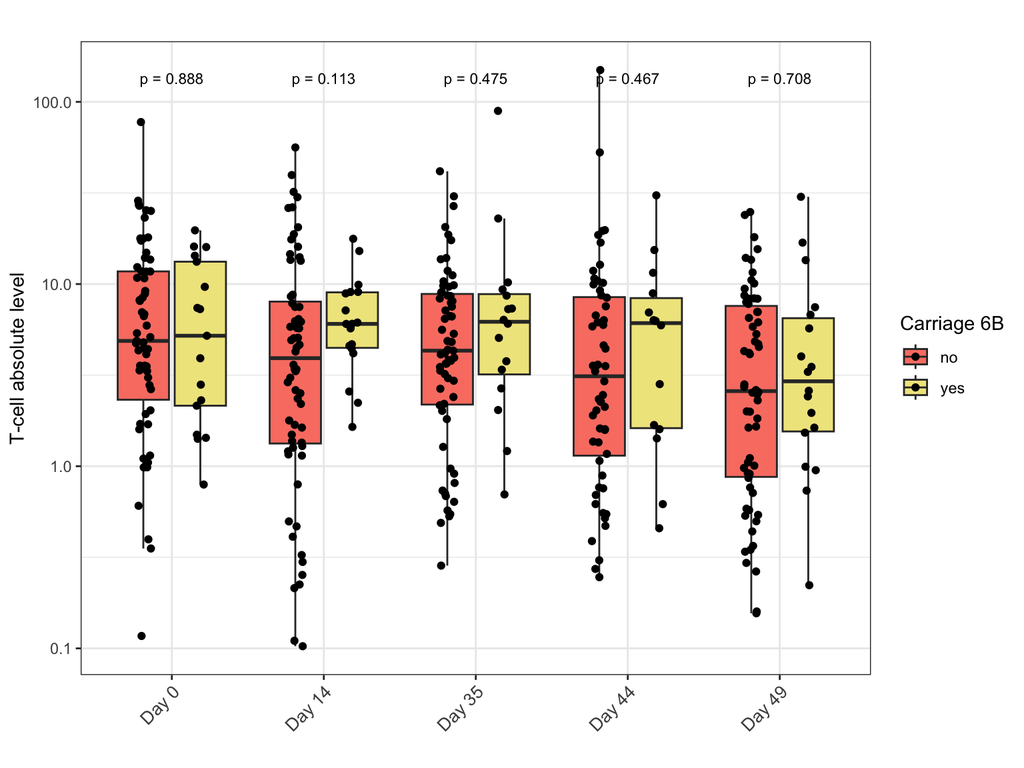

Figure 18: Comparison of day 0, 14, 35, 44 and 49 T-cell absolute levels between experimental carriage groups.

```r
# Reshape data to long format
ntr_long <- mv130df_pp %>%
  dplyr::select(pid, carriage_6B, studyArm, tcellAbsDay0, tcellAbsDay14, tcellAbsDay35, tcellAbsDay44, tcellAbsDay49) %>%
  pivot_longer(
    cols = c(tcellAbsDay0, tcellAbsDay14, tcellAbsDay35, tcellAbsDay44, tcellAbsDay49),
    names_to = "Day",
    values_to = "tcellAbs"
  )

# Convert 'Day' to a factor
ntr_long$Day <- factor(ntr_long$Day, levels = c("tcellAbsDay0", "tcellAbsDay14", "tcellAbsDay35", "tcellAbsDay44", "tcellAbsDay49"), labels = c("Day 0", "Day 14", "Day 35", "Day 44", "Day 49"))


ggplot(ntr_long, aes(x = Day, y = tcellAbs, fill = carriage_6B)) +
  geom_boxplot(outlier.shape = NA) +
  geom_point(position = position_jitterdodge(jitter.width = 0.2))+
  labs(
    title = "",
    x = "",
    y = "T-cell absolute level",
    color = "6B carriage"
  ) +
  theme_bw() +
  theme(axis.text.x = element_text(angle = 45, hjust = 1, size = 10)) +
  scale_y_log10() +
  scale_fill_manual(values = c("yes" = "khaki", "no" = "salmon"), name="Carriage 6B") +
  theme(
    plot.title = element_text(hjust = 0.5),
  )+
  stat_compare_means(method = "wilcox.test", aes(group=carriage_6B, label = ifelse(..p.. < 0.001, "p < 0.001", sprintf("p = %.3f", ..p..))), label.x = 1.5, label.y = 2.1, size = 3)
```

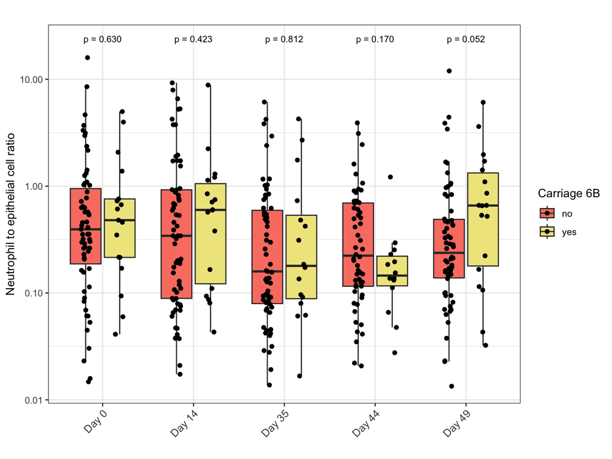

Figure 19: Comparison of day 0, 14, 35, 44 and 49 neutrophil to epithelial cell ratios between experimental carriage groups.

```r
# Reshape data to long format
ntr_long <- mv130df_pp %>%
  dplyr::select(pid, carriage_6B, studyArm, neutroEpithRatioDay0, neutroEpithRatioDay14, neutroEpithRatioDay35, neutroEpithRatioDay44, neutroEpithRatioDay49) %>%
  pivot_longer(
    cols = c(neutroEpithRatioDay0, neutroEpithRatioDay14, neutroEpithRatioDay35, neutroEpithRatioDay44, neutroEpithRatioDay49),
    names_to = "Day",
    values_to = "neutroEpithRatio"
  )

# Convert 'Day' to a factor
ntr_long$Day <- factor(ntr_long$Day, levels = c("neutroEpithRatioDay0", "neutroEpithRatioDay14", "neutroEpithRatioDay35", "neutroEpithRatioDay44", "neutroEpithRatioDay49"), labels = c("Day 0", "Day 14", "Day 35", "Day 44", "Day 49"))


ggplot(ntr_long, aes(x = Day, y = neutroEpithRatio, fill = carriage_6B)) +
  geom_boxplot(outlier.shape = NA) +
  geom_point(position = position_jitterdodge(jitter.width = 0.2))+
  labs(
    title = "",
    x = "",
    y = "Neutrophil to epithelial cell ratio",
    color = "6B carriage"
  ) +
  theme_bw() +
  theme(axis.text.x = element_text(angle = 45, hjust = 1, size = 10)) +
  scale_y_log10() +
  scale_fill_manual(values = c("yes" = "khaki", "no" = "salmon"), name="Carriage 6B") +
  theme(
    plot.title = element_text(hjust = 0.5),
  )+
  stat_compare_means(method = "wilcox.test", aes(group=carriage_6B, label = ifelse(..p.. < 0.001, "p < 0.001", sprintf("p = %.3f", ..p..))), label.x = 1.5, label.y = 1.35, size = 3)
```

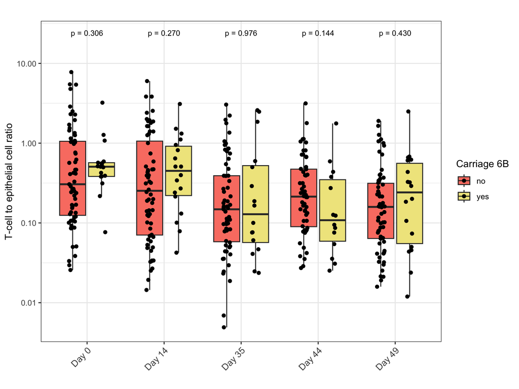

Figure 20: Comparison of day 0, 14, 35, 44 and 49 T-cell to epithelial cell ratios between experimental carriage groups.

```r
# Reshape data to long format
ntr_long <- mv130df_pp %>%
  dplyr::select(pid, carriage_6B, studyArm, tcellEpithRatioDay0, tcellEpithRatioDay14, tcellEpithRatioDay35, tcellEpithRatioDay44, tcellEpithRatioDay49) %>%
  pivot_longer(
    cols = c(tcellEpithRatioDay0, tcellEpithRatioDay14, tcellEpithRatioDay35, tcellEpithRatioDay44, tcellEpithRatioDay49),
    names_to = "Day",
    values_to = "tcellEpithRatio"
  )

# Convert 'Day' to a factor
ntr_long$Day <- factor(ntr_long$Day, levels = c("tcellEpithRatioDay0", "tcellEpithRatioDay14", "tcellEpithRatioDay35", "tcellEpithRatioDay44", "tcellEpithRatioDay49"), labels = c("Day 0", "Day 14", "Day 35", "Day 44", "Day 49"))


ggplot(ntr_long, aes(x = Day, y = tcellEpithRatio, fill = carriage_6B)) +
  geom_boxplot(outlier.shape = NA) +
  geom_point(position = position_jitterdodge(jitter.width = 0.2))+
  labs(
    title = "",
    x = "",
    y = "T-cell to epithelial cell ratio",
    color = "6B carriage"
  ) +
  theme_bw() +
  theme(axis.text.x = element_text(angle = 45, hjust = 1, size = 10)) +
  scale_y_log10() +
  scale_fill_manual(values = c("yes" = "khaki", "no" = "salmon"), name="Carriage 6B") +
  theme(
    plot.title = element_text(hjust = 0.5),
  )+
  stat_compare_means(method = "wilcox.test", aes(group=carriage_6B, label = ifelse(..p.. < 0.001, "p < 0.001", sprintf("p = %.3f", ..p..))), label.x = 1.5, label.y = 1.35, size = 3)
```

### 10.6.5 Adjusted analysis of NTR data using a multiple linear regression model

#### 10.6.5.1 Model Specification

- Outcome Variable: NTR at Day 14 (log-transformed given non-normality of the NTR data).
- Independent Variables: Treatment group (MV130 vs. Placebo). Baseline characteristics: Age, sex, prior infections (baseline carriage for NC and NVT), and baseline NTR.

#### 10.6.5.2 Results

```r
mv130df_pp <- mv130df_pp %>%
  dplyr::mutate(
    priorCarriage = case_when(carriageD0_NC==1 ~ 1, TRUE~0),
    ageCentered=age-20
  )

# multiple linear regression model
adjusted_model <- glm(log(ntrDay14) ~ studyArm + ageCentered + sex + log(ntrDay0) + priorCarriage, data = mv130df_pp)

# Create a tidy summary with confidence intervals
model_summary <- tidy(adjusted_model, conf.int = TRUE)

model_summary$estimate <- round(model_summary$estimate, digits = 3)
model_summary$std.error <- round(model_summary$std.error, digits = 3)
model_summary$statistic <- round(model_summary$statistic, digits = 3)
model_summary$p.value <- round(model_summary$p.value, digits = 3)
model_summary$conf.low <- round(model_summary$conf.low, digits = 3)
model_summary$conf.high <- round(model_summary$conf.high, digits = 3)

caption <- paste0(
  "Summary of the adjusted linear regression model fit. ",
  "The results show ", ifelse(model_summary$p.value[2] < 0.05, "a", "no"),
  " statistically significant effect of study arm on NTR at Day 14 (β = ",
  format(round(model_summary$estimate[2], 2), nsmall = 2),
  ", 95% CI (",
  paste0(format(round(model_summary$conf.low[2], 2), nsmall = 2), ", ",
         format(round(model_summary$conf.high[2], 2), nsmall = 2)),
  "), p ", ifelse(model_summary$p.value[2] >= 0.001,
      paste0("= ", format(round(model_summary$p.value[2], 3), nsmall = 3)),
      "< 0.001"), ")."
)

# Formatted table
model_summary %>%
  dplyr::select(term,estimate,conf.low,conf.high,p.value) %>%
  kable(row.names=FALSE,col.names = c("Variable", "Estimate", "CI Lower", "CI Upper", "p-value"),caption = caption) %>%
  kable_styling(full_width=FALSE)
```

Table 9: Multiple linear regression model for log(day 14 NTR) adjusted for participant characteristics.

Summary of the adjusted linear regression model fit. The results show no statistically significant effect of study arm on NTR at Day 14 (β = 0.08, 95% CI (-0.48, 0.64), p = 0.775).

| Variable | Estimate | CI Lower | CI Upper | p-value |
| --- | --- | --- | --- | --- |
| (Intercept) | 0.210 | -0.549 | 0.970 | 0.590 |
| studyArmPlacebo | 0.082 | -0.475 | 0.638 | 0.775 |
| ageCentered | -0.007 | -0.067 | 0.053 | 0.820 |
| sexMale | -0.248 | -0.827 | 0.331 | 0.404 |
| log(ntrDay0) | 0.286 | 0.006 | 0.566 | 0.050 |
| priorCarriage | 0.463 | -0.111 | 1.037 | 0.119 |

#### 10.6.5.3 Model diagnostics

##### 10.6.5.3.1 Residuals vs fitted

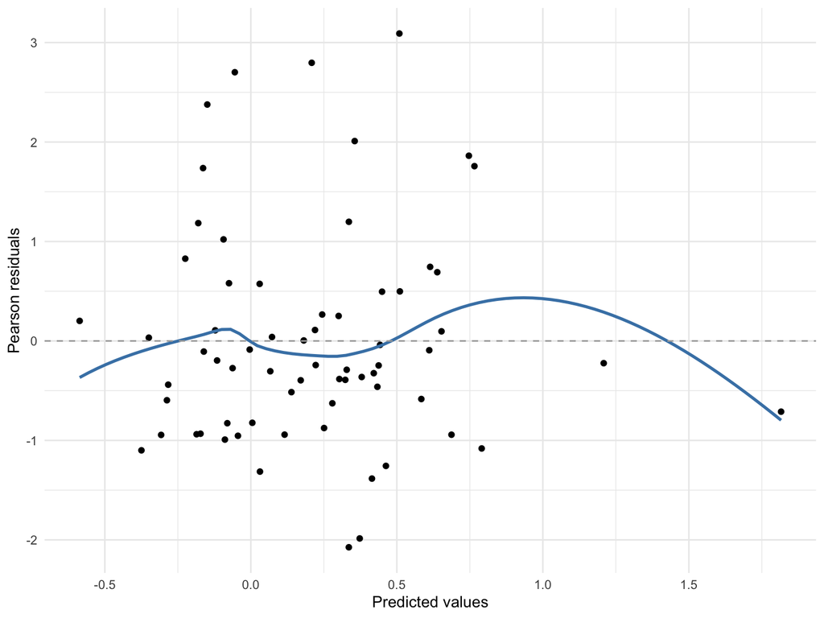

Figure 21: Fitted vs. residuals plot for the adjusted linear model for log-transformed NTR at day 14.

```r
dfResPred<-data.frame(
  pid=mv130df_pp$pid[as.integer(names(predict(adjusted_model,na.action=na.pass)))],
  pred=predict(adjusted_model,na.action=na.pass),
  res=residuals(adjusted_model,na.action=na.pass,type="pearson")
)

dfResPred %>%
  ggplot(mapping=aes(x=pred,y=res)) +
  geom_point() +
  geom_smooth(se=FALSE,col="steelblue",lwd=1) +
  geom_hline(yintercept = 0,lty=2,col="darkgrey") +
  theme_minimal() +
  xlab("Predicted values") +
  ylab("Pearson residuals")
```

There are two values with somewhat larger predicted values. These are participants MV10130, MV10304.

Otherwise, the residuals do look approximately normally distributed and with constant variance.

##### 10.6.5.3.2 Influential observations

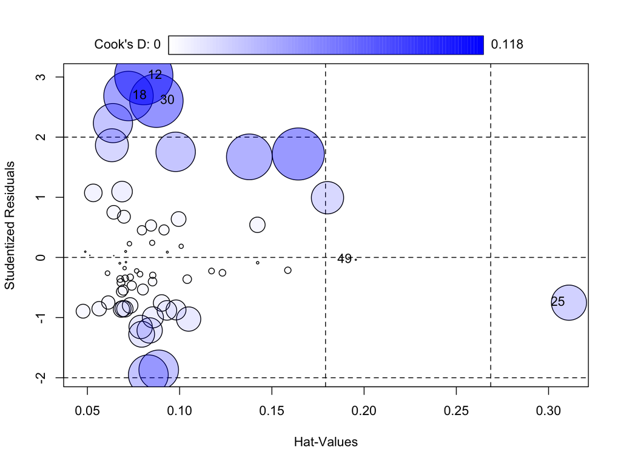

Figure 22: Influence plot for the adjusted linear model for log-transformed NTR at day 14.

```r
inf<-influencePlot(adjusted_model)
```

Looking at observations with high leverage, 5 observations are highlighted: participants MV10148, MV10239, MV10304, MV10379, MV10627.

```r
pids2RemoveForSens<-mv130df_pp$pid[as.integer(rownames(inf))]
```

##### 10.6.5.3.3 Sensitivity analysis

As a sensitivity analysis we remove the observations flagged as influential observations. These are observations MV10148, MV10239, MV10304, MV10379, MV10627.

```r
adjusted_model_sensitivity <- glm(log(ntrDay14) ~ studyArm + ageCentered + sex + log(ntrDay0) + priorCarriage, data = mv130df_pp %>% dplyr::filter(!(pid %in% pids2RemoveForSens)))

model_summary <- tidy(adjusted_model_sensitivity, conf.int = TRUE)

model_summary$estimate <- round(model_summary$estimate, digits = 3)
model_summary$std.error <- round(model_summary$std.error, digits = 3)
model_summary$statistic <- round(model_summary$statistic, digits = 3)
model_summary$p.value <- round(model_summary$p.value, digits = 3)
model_summary$conf.low <- round(model_summary$conf.low, digits = 3)
model_summary$conf.high <- round(model_summary$conf.high, digits = 3)

caption <- paste0(
  "Summary of the adjusted linear regression model fit. ",
  "The results show ", ifelse(model_summary$p.value[2] < 0.05, "a", "no"),
  " statistically significant effect of study arm on NTR at Day 14 (β = ",
  format(round(model_summary$estimate[2], 2), nsmall = 2),
  ", 95% CI (",
  paste0(format(round(model_summary$conf.low[2], 2), nsmall = 2), ", ",
         format(round(model_summary$conf.high[2], 2), nsmall = 2)),
  "), p ", ifelse(model_summary$p.value[2] >= 0.001,
      paste0("= ", format(round(model_summary$p.value[2], 3), nsmall = 3)),
      "< 0.001"), ")."
)

model_summary %>%
  dplyr::select(term,estimate,conf.low,conf.high,p.value) %>%
  kable(row.names=FALSE,col.names = c("Variable", "Estimate", "CI Lower", "CI Upper", "p-value"),caption = caption) %>%
  kable_styling(full_width=FALSE)
```

Table 10: Summary table for the sensitivity analysis for the multiple linear regression model for log(day 14 NTR) adjusted for participant characteristics after removing potentially influential observations.

Summary of the adjusted linear regression model fit. The results show no statistically significant effect of study arm on NTR at Day 14 (β = 0.22, 95% CI (-0.28, 0.72), p = 0.393).

| Variable | Estimate | CI Lower | CI Upper | p-value |
| --- | --- | --- | --- | --- |
| (Intercept) | -0.211 | -0.910 | 0.488 | 0.557 |
| studyArmPlacebo | 0.219 | -0.280 | 0.718 | 0.393 |
| ageCentered | 0.012 | -0.043 | 0.067 | 0.668 |
| sexMale | -0.137 | -0.653 | 0.379 | 0.605 |
| log(ntrDay0) | 0.350 | 0.075 | 0.624 | 0.015 |
| priorCarriage | 0.529 | 0.011 | 1.047 | 0.050 |

We re-fit the model without the potentially influential observations; this model now has an R<sup>2</sup> of 16.25. The conclusion regarding the effect of study arm remains the same: no statistically significant effect.

### 10.6.6 Comparison of experimental pneumococcal carriage between study arms

#### 10.6.6.1 Unadjusted analysis

```r
pvalue <- function(x, ...) {
    # Construct vectors of data y, and groups (strata) g
    y <- unlist(x)
    g <- factor(rep(1:length(x), times=sapply(x, length)))
    if (is.numeric(y)) {
        # For numeric variables, perform a standard 2-sample t-test
        p <- t.test(y ~ g)$p.value
    } else {
        # For categorical variables, perform a chi-squared test of independence
        p <- fisher.test(table(y, g))$p.value
    }
    #format p-value
  formatted_p <- if (p < 0.001) "<0.001" else sprintf("%.3f", p)
}

tab2x2 <- table(factor(mv130df_pp$studyArm,levels=c("Placebo","MV130")), mv130df_pp$carriage_6B)
rrUnadj<-riskratio(tab2x2)

rrUnadj<-paste0(format(nsmall=2,round(digits=2,rrUnadj$measure["MV130","estimate"])),", 95% CI (",paste(collapse=",",format(nsmall=2,round(digits=2,rrUnadj$measure["MV130",c("lower","upper")]))),")")

carriageTab <- table1(~carriage_6B | studyArm, data=mv130df_pp, overall=F, extra.col=list(`P-value`=pvalue),caption = paste0("The carriage risk ratio for the MV130 arm compared to the placebo arm is estimated to be ",rrUnadj,"."))
carriageTab
```

Table 11: Comparison of experimental 6B carriage between study arms.

The carriage risk ratio for the MV130 arm compared to the placebo arm is estimated to be 1.02, 95% CI (0.49,2.12).

|  | MV130 (N=52) | Placebo (N=44) | P-value |
| --- | --- | --- | --- |
| carriage_6B |  |  | 1.000 |
| no | 40 (76.9%) | 34 (77.3%) |  |
| yes | 12 (23.1%) | 10 (22.7%) |  |

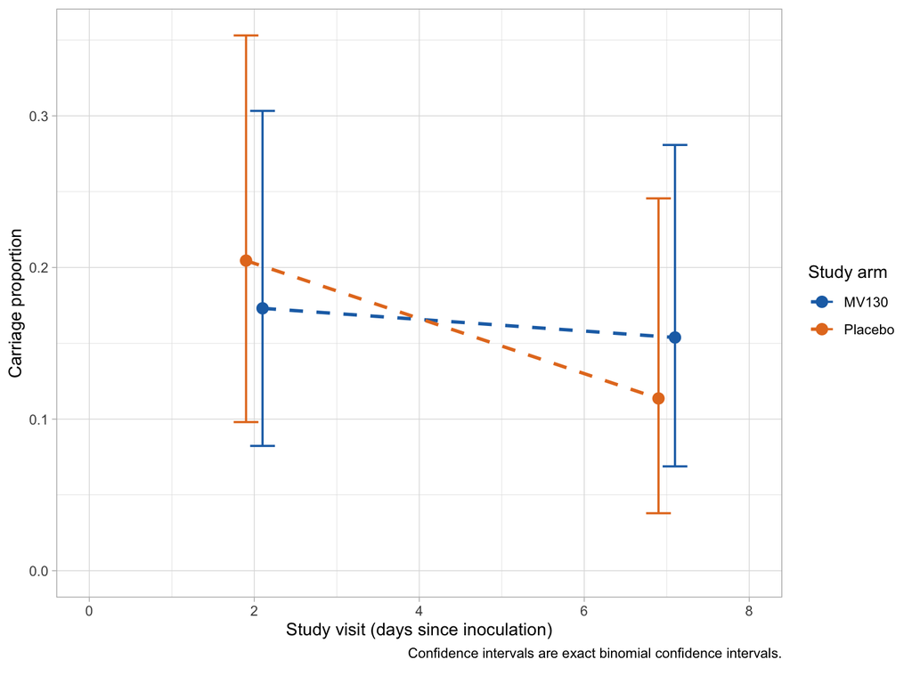

Figure 23: Serotype 6B carriage proportions per study arm at post-inoculation visits.

```r
plotDatLine<- mv130df_pp %>%
  dplyr::select(pid,studyArm,carriageD44_6B ,carriageD49_6B) %>%
  pivot_longer(cols=c(carriageD44_6B ,carriageD49_6B),names_to="visit",values_to="carriage") %>%
  mutate(
    carriers = case_when(
      carriage == 1 ~ 1,
      TRUE~0
    ),
    visit = case_when(
      visit=="carriageD44_6B"~"D44",
      visit=="carriageD49_6B"~"D49"
    )
  ) %>%
  group_by(studyArm,visit) %>%
  dplyr::summarise(
    n=sum(!is.na(carriers)),
    k=sum(carriers, na.rm = T),
    .groups="drop") %>%
  mutate(
    prop=k/n,
    propLow=NA,
    propUpp=NA
  ) %>%
  mutate(
    visitNum=case_when(
      visit=="D44"~2,
      visit=="D49"~7,
      TRUE~NA_real_
    ))

for(j in 1:nrow(plotDatLine)){
  ci<-binom.test(x=plotDatLine$k[j],n=plotDatLine$n[j])$conf.int
  plotDatLine$propLow[j]<-ci[1]
  plotDatLine$propUpp[j]<-ci[2]
  rm(ci)
}

yMax<-max(plotDatLine$propUpp)

 plotDatLine %>%
  ggplot(mapping=aes(x=visitNum+ifelse(studyArm=="MV130",0.1,-0.1),y=prop,ymin=propLow,ymax=propUpp,col=studyArm)) +
  geom_line(lty=2,lwd=1) +
  geom_point(size=3) +
  geom_errorbar(width=0.3,lwd=0.65) +
  scale_color_manual(values=c("#1f70b4","#e57a23"),name="Study arm") +
  xlab("Study visit (days since inoculation)") +
  ylab("Carriage proportion") +
  xlim(c(0,8)) +
  ylim(c(0,yMax)) +
  guides(fill="none") +
  theme_light() +
  labs(caption="Confidence intervals are exact binomial confidence intervals.\n")
```

#### 10.6.6.2 Adjusted analysis

```r
mv130df_pp<-mv130df_pp %>%
  dplyr::mutate(studyArm=factor(studyArm,level=c("Placebo","MV130")))

#Log-binomial regression for carriage status
logbin_model <- logbin(factor(carriage_6B,levels=c("no","yes")) ~ studyArm + ageCentered + sex + priorCarriage, data = mv130df_pp, method="em")

model_summary <- tidy(logbin_model, conf.int = TRUE)

model_summary$estimate <- round(exp(model_summary$estimate), digits = 3)
model_summary$std.error <- round(model_summary$std.error, digits = 3)
model_summary$statistic <- round(model_summary$statistic, digits = 3)
model_summary$p.value <- round(model_summary$p.value, digits = 3)
model_summary$conf.low <- round(exp(model_summary$conf.low), digits = 3)
model_summary$conf.high <- round(exp(model_summary$conf.high), digits = 3)

caption <- paste0(
  "Summary of the adjusted log-binomial regression model fit. ",
  "The results show ", ifelse(model_summary$p.value[2] < 0.05, "a", "no"),
  " statistically significant effect of study arm on pneumococcal carriage (RR = ",
  format(round(model_summary$estimate[2], 2), nsmall = 2),
  ", 95% CI (",
  paste0(format(round(model_summary$conf.low[2], 2), nsmall = 2), ", ",
         format(round(model_summary$conf.high[2], 2), nsmall = 2)),
  "), p ", ifelse(model_summary$p.value[2] >= 0.001,
      paste0("= ", format(round(model_summary$p.value[2], 3), nsmall = 3)),
      "< 0.001"), ")."
)

# Formatted table
model_summary %>%
  dplyr::select(term,estimate,conf.low,conf.high,p.value) %>%
  kable(row.names=FALSE,col.names = c("Variable", "Estimate", "CI Lower", "CI Upper", "p-value"),caption = caption) %>%
  kable_styling(full_width=FALSE)
mv130df_pp<-mv130df_pp %>%
  dplyr::mutate(studyArm=factor(studyArm,level=c("MV130","Placebo")))
```

Table 12: Summary of the log-binomial regression model for experimental 6B carriage.

Summary of the adjusted log-binomial regression model fit. The results show no statistically significant effect of study arm on pneumococcal carriage (RR = 1.15, 95% CI (0.57, 2.33), p = 0.699).

| Variable | Estimate | CI Lower | CI Upper | p-value |
| --- | --- | --- | --- | --- |
| (Intercept) | 0.138 | 0.048 | 0.392 | 0.000 |
| studyArmMV130 | 1.149 | 0.567 | 2.330 | 0.699 |
| ageCentered | 1.074 | 1.004 | 1.148 | 0.037 |
| sexMale | 1.175 | 0.565 | 2.442 | 0.666 |
| priorCarriage | 0.269 | 0.069 | 1.058 | 0.060 |

### 10.6.7 Carriage density

We can visually summarise the carriage density data per serotype (experimental / natural), study arm and study visit.

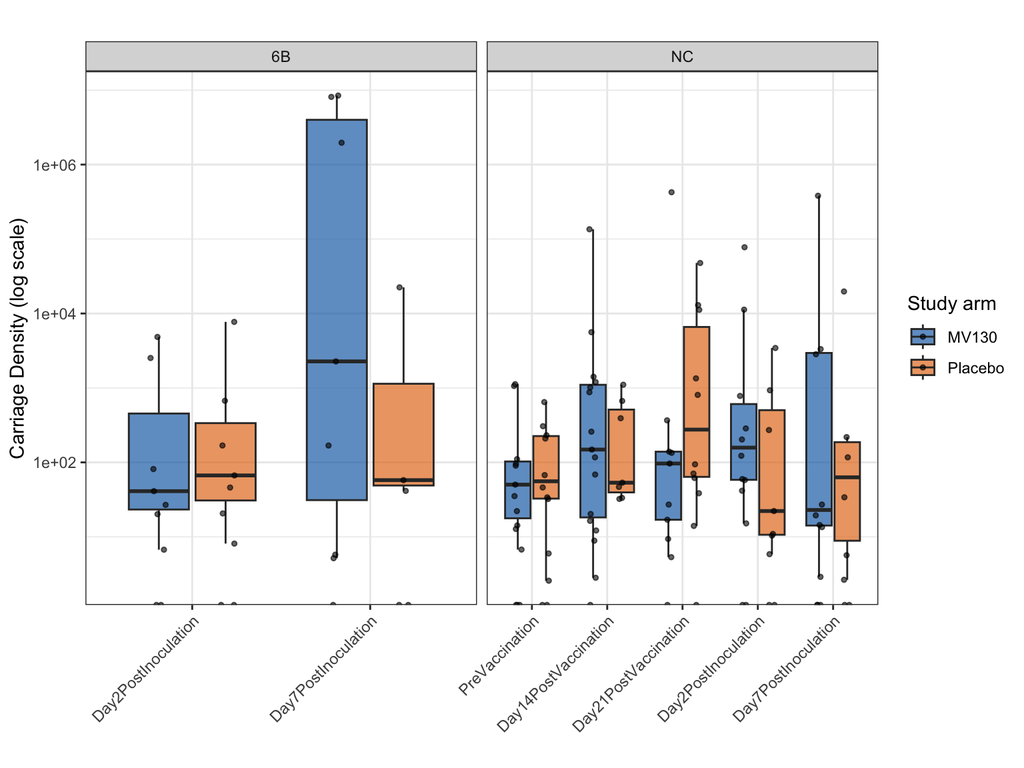

Figure 24: Carriage density by experimental / natural serotype, study arm and study visit.

```r
mv130df_long <- mv130df_pp %>%
  dplyr::select(studyArm,
         carriageD44_6B_density, carriageD49_6B_density,
         carriageD0_NC_density, carriageD14_NC_density, carriageD21_NC_density, carriageD44_NC_density, carriageD49_NC_density) %>%
  pivot_longer(cols = -studyArm, names_to = "timepoint", values_to = "density") %>%
  mutate(category = case_when(
    grepl("6B", timepoint) ~ "6B",
    grepl("NC", timepoint) ~ "NC",
    TRUE ~ "Other"
  )) %>%
  mutate(time = case_when(
    grepl("D0", timepoint) ~ "PreVaccination",
    grepl("D14", timepoint) ~ "Day14PostVaccination",
    grepl("D21", timepoint) ~ "Day21PostVaccination",
    grepl("D44", timepoint) ~ "Day2PostInoculation",
    grepl("D49", timepoint) ~ "Day7PostInoculation"
  ))

mv130df_long$time <- factor(mv130df_long$time, levels = c("PreVaccination", "Day14PostVaccination", "Day21PostVaccination", "Day2PostInoculation", "Day7PostInoculation"))

# Create a faceted plot
ggplot(mv130df_long, aes(x = time, y = density, fill = studyArm)) +
  geom_boxplot(outlier.shape = NA, alpha = 0.7) +
  geom_jitter(position = position_jitterdodge(jitter.width = 0.2), size = 1, alpha = 0.6) +
  scale_y_log10() + # Log-scale for visualization
  theme_bw() +
  labs(title = "",
       x = "",
       y = "Carriage Density (log scale)",
       fill = "Study Arm") +
  scale_fill_manual(values = c("MV130" = "#1f70b4", "Placebo" = "#e57a23"), name="Study arm") +
  theme(axis.text.x = element_text(angle = 45, hjust = 1)) +
  facet_wrap(~category, scales = "free_x")  # Facet by 6B, NC, and NVT
```

### 10.6.8 Immune response

#### 10.6.8.1 IgA and IgG expressions

No data on this for now, so this section is left blank at this time.

### 10.6.9 Comparison of Analysed vs. Excluded Participant

```r
label(mv130df$age)<-"Age"
label(mv130df$sex)<-"Sex"
label(mv130df$ntrDay0)<-"NTR at day 0"
label(mv130df$bmi)<-"BMI"
mv130df$perProtocol<-factor(mv130df$perProtocol,levels=c("0","1"),labels=c("Excluded","Analysed"))

(table1_obj <- table1(~ age + sex + ntrDay0 + bmi | factor(perProtocol),
                       data = mv130df,
                       overall = F,
                       extra.col=list(`P-value`=pvalue))
)
```

|  | Excluded (N=22) | Analysed (N=96) | P-value |
| --- | --- | --- | --- |
| Age |  |  | 0.253 |
| Mean (SD) | 29.0 (6.84) | 27.2 (4.76) |  |
| Median [Min, Max] | 28.6 [19.0, 41.5] | 26.8 [18.3, 39.3] |  |
| Sex |  |  | 0.012 |
|  | 2 (9.1%) | 0 (0%) |  |
| Female | 12 (54.5%) | 43 (44.8%) |  |
| Male | 8 (36.4%) | 53 (55.2%) |  |
| NTR at day 0 |  |  | 0.775 |
| Mean (SD) | 1.91 (1.86) | 2.18 (6.26) |  |
| Median [Min, Max] | 1.20 [0.107, 5.40] | 0.933 [0.0852, 55.3] |  |
| Missing | 12 (54.5%) | 16 (16.7%) |  |
| BMI |  |  | 0.092 |
| Mean (SD) | 22.3 (3.38) | 23.9 (4.56) |  |
| Median [Min, Max] | 21.1 [17.5, 29.3] | 22.5 [17.3, 42.4] |  |
| Missing | 2 (9.1%) | 0 (0%) |  |

### 10.6.10 Comparison of NTR and carriage between compliant and non-compliant MV130-randomised study participants

#### 10.6.10.1 NTR comparison between compliant and non-compliant MV130 recipients

We can first summarise the compliance data. Participants were considered to be compliant based on self-reporting (number of days they completed the treatment) and bottle-weight at the end of the study:

- Self-compliance is defined to have reported taking the treatment on at least 38 days out of 42 total days (this corresponds to 90% compliance).
- Bottle-weight compliance is defined as having a final bottle-weight of 30g or less (10g corresponds to 84 sprays and initial bottle-weights were 39g; 9g taken corresponds to 90% compliance).
- Overall compliance is defined as being compliance both on self-report and bottle-weight.

90.4% of participants in the MV130 arm are compliant according to self-report, 67.3% according to bottle-weight and 63.5% of MV130 randomised participants are overall compliant (i.e. both by self-report and bottle-weight).

```r
dfComplianceDataForVusi<-mv130df_pp %>%
  dplyr::select(pid,studyArm,age,sex,complianceSelf,complianceBw,compliance)

dfCompliance<-rbind(
  table(mv130df_pp$studyArm,mv130df_pp$complianceSelf),
  table(mv130df_pp$studyArm,mv130df_pp$complianceBw),
  table(mv130df_pp$studyArm,mv130df_pp$compliance)
)

dfCompliance<-data.frame(
  Compliance=c(rep("Self-report",2),rep("Bottle-weight",2),rep("Overall",2)),
  StudyArm=rownames(dfCompliance),
  NonCompliant=dfCompliance[,1],
  Compliant=dfCompliance[,2]
)

dfCompliance %>%
  dplyr::select(StudyArm,NonCompliant,Compliant) %>%
  kable(row.names=FALSE,col.names=c(" ","Non-compliant","Compliant")) %>%
  kable_styling(full_width = FALSE) %>%
  pack_rows("Self-reported compliance",1,2) %>%
  pack_rows("Bottle-weight compliance",3,4) %>%
  pack_rows("Overall compliance",5,6)
```

Table 13: Summary of the compliance data by study arm.

|  | Non-compliant | Compliant |
| --- | --- | --- |
| **Self-reported compliance** |  |  |
| MV130 | 5 | 47 |
| Placebo | 0 | 44 |
| **Bottle-weight compliance** |  |  |
| MV130 | 17 | 35 |
| Placebo | 8 | 36 |
| **Overall compliance** |  |  |
| MV130 | 19 | 33 |
| Placebo | 8 | 36 |

We can then compare NTR between compliant and non-compliant MV130 randomised participants.

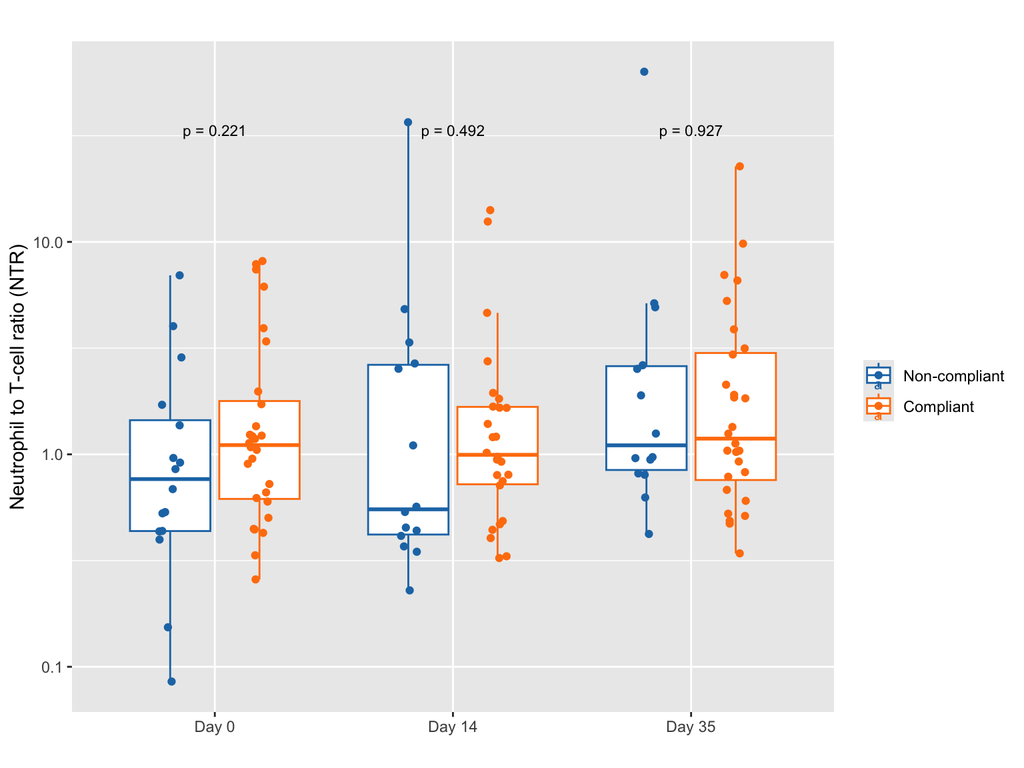

Figure 25: NTR at days 0, 14 and 35 by compliance status for MV130 randomised participants. P-value at the top of each study visit are comparing NTR between compliance groups using a two-sample Wilcoxon rank-sum test.

```r
# Reshape data to long format
ntr_compliance_long <- mv130df_pp %>%
  dplyr::filter(studyArm=="MV130") %>%
  dplyr::select(pid, compliance, carriage_6B, ntrDay0, ntrDay14, ntrDay35) %>%
  pivot_longer(
    cols = c(ntrDay0, ntrDay14, ntrDay35),
    names_to = "Day",
    values_to = "NTR"
  )

# Convert 'Day' to a factor
ntr_compliance_long$Day <- factor(ntr_compliance_long$Day, levels = c("ntrDay0","ntrDay14","ntrDay35"), labels = c("Day 0","Day 14","Day 35"))

ggplot(ntr_compliance_long, aes(x = Day, y = NTR, color = compliance)) +
  geom_boxplot(outlier.shape = NA) +
  geom_point(position = position_jitterdodge(jitter.width = 0.2))+
  labs(
    title = "",
    x = "",
    y = "Neutrophil to T-cell ratio (NTR)"
  ) +
  scale_y_log10() +
  scale_color_manual(values = c("Non-compliant" = "#1f77b4", "Compliant" = "#ff7f0e"),name="") +
  theme(
    plot.title = element_text(hjust = 0.5),
  )+
  stat_compare_means(method = "wilcox.test", aes(group=compliance, label = ifelse(..p.. < 0.001, "p < 0.001", sprintf("p = %.3f", ..p..))), label.y = 1.5, size = 3)
```

#### 10.6.10.2 Carriage comparison between compliant and non-compliant MV130 recipients

```r
pvalue <- function(x, ...) {
    # Construct vectors of data y, and groups (strata) g
    y <- unlist(x)
    g <- factor(rep(1:length(x), times=sapply(x, length)))
    if (is.numeric(y)) {
        # For numeric variables, perform a standard 2-sample t-test
        p <- t.test(y ~ g)$p.value
    } else {
        # For categorical variables, perform a chi-squared test of independence
        p <- fisher.test(table(y, g))$p.value
    }
    #format p-value
  formatted_p <- if (p < 0.001) "<0.001" else sprintf("%.3f", p)
}


(carriageTab <- table1(~carriage_6B | compliance, mv130df_pp %>% dplyr::filter(studyArm=="MV130"), overall=F, extra.col=list(`P-value`=pvalue)))
```

Table 14: Experimental pneumococcal carriage (serotype 6B) at any timepoint by compliance status. P-value estimated using Fisher’s exact test.

|  | Non-compliant (N=19) | Compliant (N=33) | P-value |
| --- | --- | --- | --- |
| carriage_6B |  |  | 0.739 |
| no | 14 (73.7%) | 26 (78.8%) |  |
| yes | 5 (26.3%) | 7 (21.2%) |  |

#### 10.6.10.3 Primary NTR analysis, stratified by compliance status

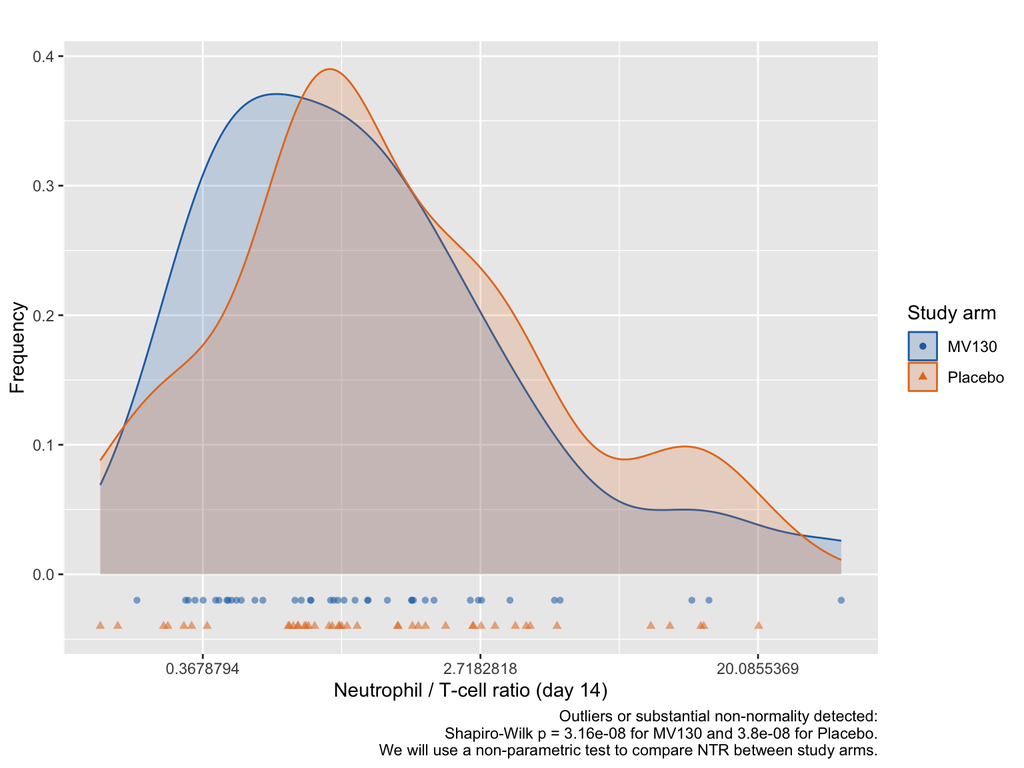

```r
normality_test <- mv130df_pp %>%
  dplyr::filter(compliance=="Compliant") %>%
  dplyr::group_by(studyArm) %>%
  dplyr::summarise(
    normality_p_value = shapiro.test(ntrDay14)$p.value,
    .groups = "drop"
  )

# Plot NTR at Day 14 by intervention arm
ggplot(mv130df_pp, mapping=aes(x = ntrDay14, fill = studyArm)) +
  geom_density(mapping=aes(col=studyArm),position="dodge",alpha=0.2) +
  geom_point(mapping=aes(y=ifelse(studyArm=="MV130",-0.02,-0.04),alpha=0.5,col=studyArm,pch=studyArm)) +
  labs(
    title = "",
    x = "Neutrophil / T-cell ratio (day 14)",
    y = "Frequency",
    caption = ifelse(sum(normality_test$normality_p_value < 0.05)>0,
                       paste(sep="","Outliers or substantial non-normality detected:\nShapiro-Wilk p = ",signif(normality_test$normality_p_value[1],digits=3)," for ",normality_test$studyArm[1]," and ",signif(normality_test$normality_p_value[2],digits=3)," for ",normality_test$studyArm[2],".\nWe will use a non-parametric test to compare NTR between study arms."),
                       "No severe outliers or other substantial non-normality are obvious.\nThe use of a t-test for comparing NTR between study arms is appropriate.")
) +
  scale_fill_manual(values = c("MV130" = "#1f70b4", "Placebo" = "#e57a23"), name="Study arm") +
  scale_colour_manual(values = c("MV130" = "#1f70b4", "Placebo" = "#e57a23"), name="Study arm") +
  scale_shape_manual(values=16:17,name="Study arm") +
  scale_x_continuous(trans="log") +
  guides(alpha="none")
```

```r
mainAnaNTRDay14_comp<-wilcox.test(ntrDay14~studyArm,data=mv130df_pp %>% dplyr::filter(compliance=="Compliant"))

mainAnaNTRDay14table_comp<-mv130df_pp %>%
  dplyr::filter(compliance=="Compliant") %>%
  dplyr::group_by(studyArm) %>%
  dplyr::summarise(
    n=sum(!is.na(ntrDay14)),
    median=format(nsmall=3,round(digits=3,median(ntrDay14,na.rm=T))),
    Q25=format(nsmall=3,round(digits=3,quantile(ntrDay14,prob=0.25,na.rm=T))),
    Q75=format(nsmall=3,round(digits=3,quantile(ntrDay14,prob=0.75,na.rm=T)))
  ) %>%
  dplyr::mutate(
    IQR=paste(sep="","(",Q25,",",Q75,")")
  ) %>%
  dplyr::select(studyArm,n,median,IQR)

mainAnaNTRDay14table_comp %>%
  knitr::kable(row.names=FALSE,col.names=c("Study arm","n","Median","IQR"),caption=paste(sep="","Wilcoxon rank-sum test comparing NTR at day 14 between study arms for compliant participants: p = ",format(nsmall=3,round(digits=3,mainAnaNTRDay14_comp$p.value)))) %>%
  kableExtra::kable_styling(full_width = FALSE)
```

Table 15: Comparison of NTR at day 14 between study arms for compliant participants.

Wilcoxon rank-sum test comparing NTR at day 14 between study arms for compliant participants: p = 0.651

| Study arm | n | Median | IQR |
| --- | --- | --- | --- |
| MV130 | 26 | 0.995 | (0.723,1.673) |
| Placebo | 34 | 1.020 | (0.730,2.694) |

#### 10.6.10.4 Secondary carriage analysis, stratified by compliance status

##### 10.6.10.4.1 Unadjusted analysis

```r
pvalue <- function(x, ...) {
    # Construct vectors of data y, and groups (strata) g
    y <- unlist(x)
    g <- factor(rep(1:length(x), times=sapply(x, length)))
    if (is.numeric(y)) {
        # For numeric variables, perform a standard 2-sample t-test
        p <- t.test(y ~ g)$p.value
    } else {
        # For categorical variables, perform a chi-squared test of independence
        p <- fisher.test(table(y, g))$p.value
    }
    #format p-value
  formatted_p <- if (p < 0.001) "<0.001" else sprintf("%.3f", p)
}

mv130df_pp_comp <- mv130df_pp %>%
  dplyr::filter(compliance=="Compliant")

tab2x2 <- table(factor(mv130df_pp_comp$studyArm,levels=c("Placebo","MV130")), mv130df_pp_comp$carriage_6B )
rrUnadj<-riskratio(tab2x2)

rrUnadj<-paste0(format(nsmall=2,round(digits=2,rrUnadj$measure["MV130","estimate"])),", 95% CI (",paste(collapse=",",format(nsmall=2,round(digits=2,rrUnadj$measure["MV130",c("lower","upper")]))),")")

carriageTab <- table1(~carriage_6B | studyArm, data=mv130df_pp %>% dplyr::filter(compliance=="Compliant"), overall=F, extra.col=list(`P-value`=pvalue),caption = paste0("The carriage risk ratio for the MV130 arm compared to the placebo arm, among compliant participants, is estimated to be ",rrUnadj,"."))
carriageTab
carriageTab_D44 <- table1(~ifelse(carriageD44_6B==1,"yes","no") | studyArm, data=mv130df_pp %>% dplyr::filter(compliance=="Compliant"), overall=F, extra.col=list(`P-value`=pvalue))
carriageTab_D44
carriageTab_D49 <- table1(~ifelse(carriageD49_6B==1,"yes","no") | studyArm, data=mv130df_pp %>% dplyr::filter(compliance=="Compliant"), overall=F, extra.col=list(`P-value`=pvalue))
carriageTab_D49
```

Table 16: Comparison of experimental 6B carriage between study arms for compliant participants.

The carriage risk ratio for the MV130 arm compared to the placebo arm, among compliant participants, is estimated to be 0.95, 95% CI (0.39,2.34).

|  | MV130 (N=33) | Placebo (N=36) | P-value |
| --- | --- | --- | --- |
| carriage_6B |  |  | 1.000 |
| no | 26 (78.8%) | 28 (77.8%) |  |
| yes | 7 (21.2%) | 8 (22.2%) |  |

|  | MV130 (N=33) | Placebo (N=36) | P-value |
| --- | --- | --- | --- |
| ifelse(carriageD44_6B == 1, "yes", "no") |  |  | 0.546 |
| no | 28 (84.8%) | 28 (77.8%) |  |
| yes | 5 (15.2%) | 8 (22.2%) |  |

|  | MV130 (N=33) | Placebo (N=36) | P-value |
| --- | --- | --- | --- |
| ifelse(carriageD49_6B == 1, "yes", "no") |  |  | 0.466 |
| no | 28 (84.8%) | 33 (91.7%) |  |
| yes | 5 (15.2%) | 3 (8.3%) |  |

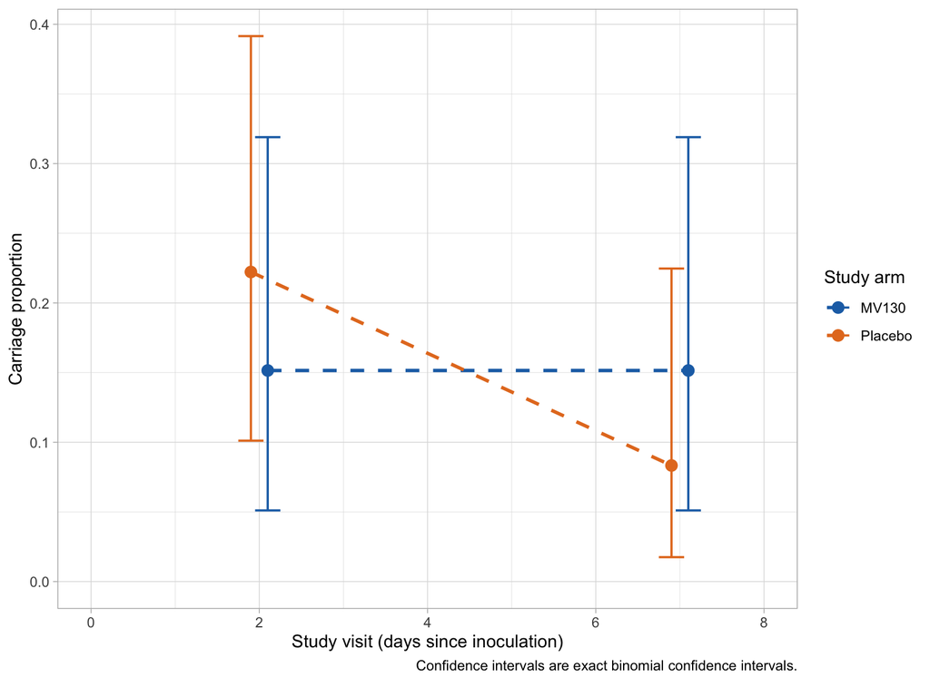

Figure 27: Serotype 6B carriage proportions per study arm at post-inoculation visits for compliant participants.

```r
plotDatLine<- mv130df_pp %>%
  dplyr::filter(compliance=="Compliant") %>%
  dplyr::select(pid,studyArm,carriageD44_6B ,carriageD49_6B) %>%
  pivot_longer(cols=c(carriageD44_6B ,carriageD49_6B),names_to="visit",values_to="carriage") %>%
  mutate(
    carriers = case_when(
      carriage == 1 ~ 1,
      TRUE~0
    ),
    visit = case_when(
      visit=="carriageD44_6B"~"D44",
      visit=="carriageD49_6B"~"D49"
    )
  ) %>%
  group_by(studyArm,visit) %>%
  dplyr::summarise(
    n=sum(!is.na(carriers)),
    k=sum(carriers, na.rm = T),
    .groups="drop") %>%
  mutate(
    prop=k/n,
    propLow=NA,
    propUpp=NA
  ) %>%
  mutate(
    visitNum=case_when(
      visit=="D44"~2,
      visit=="D49"~7,
      TRUE~NA_real_
    ))

for(j in 1:nrow(plotDatLine)){
  ci<-binom.test(x=plotDatLine$k[j],n=plotDatLine$n[j])$conf.int
  plotDatLine$propLow[j]<-ci[1]
  plotDatLine$propUpp[j]<-ci[2]
  rm(ci)
}

yMax<-max(plotDatLine$propUpp)

 plotDatLine %>%
  ggplot(mapping=aes(x=visitNum+ifelse(studyArm=="MV130",0.1,-0.1),y=prop,ymin=propLow,ymax=propUpp,col=studyArm)) +
  geom_line(lty=2,lwd=1) +
  geom_point(size=3) +
  geom_errorbar(width=0.3,lwd=0.65) +
  scale_color_manual(values=c("#1f70b4","#e57a23"),name="Study arm") +
  xlab("Study visit (days since inoculation)") +
  ylab("Carriage proportion") +
  xlim(c(0,8)) +
  ylim(c(0,yMax)) +
  guides(fill="none") +
  theme_light() +
  labs(caption="Confidence intervals are exact binomial confidence intervals.\n")
```

##### 10.6.10.4.2 Adjusted analysis

```r
mv130df_pp<-mv130df_pp %>%
  dplyr::mutate(studyArm=factor(studyArm,level=c("Placebo","MV130")))

#Log-binomial regression for carriage status
logbin_model <- logbin(factor(carriage_6B,levels=c("no","yes")) ~ studyArm + ageCentered + sex + priorCarriage, data = mv130df_pp %>% dplyr::filter(compliance=="Compliant"), method="em")

model_summary <- tidy(logbin_model, conf.int = TRUE)

model_summary$estimate <- round(exp(model_summary$estimate), digits = 3)
model_summary$std.error <- round(model_summary$std.error, digits = 3)
model_summary$statistic <- round(model_summary$statistic, digits = 3)
model_summary$p.value <- round(model_summary$p.value, digits = 3)
model_summary$conf.low <- round(exp(model_summary$conf.low), digits = 3)
model_summary$conf.high <- round(exp(model_summary$conf.high), digits = 3)

caption <- paste0(
  "Summary of the adjusted log-binomial regression model fit. ",
  "The results show ", ifelse(model_summary$p.value[2] < 0.05, "a", "no"),
  " statistically significant effect of study arm on pneumococcal carriage (RR = ",
  format(round(model_summary$estimate[2], 2), nsmall = 2),
  ", 95% CI (",
  paste0(format(round(model_summary$conf.low[2], 2), nsmall = 2), ", ",
         format(round(model_summary$conf.high[2], 2), nsmall = 2)),
  "), p ", ifelse(model_summary$p.value[2] >= 0.001,
      paste0("= ", format(round(model_summary$p.value[2], 3), nsmall = 3)),
      "< 0.001"), ")."
)

# Formatted table
model_summary %>%
  dplyr::select(term,estimate,conf.low,conf.high,p.value) %>%
  kable(row.names=FALSE,col.names = c("Variable", "Estimate", "CI Lower", "CI Upper", "p-value"),caption = caption) %>%
  kable_styling(full_width=FALSE)
mv130df_pp<-mv130df_pp %>%
  dplyr::mutate(studyArm=factor(studyArm,level=c("MV130","Placebo")))
```

Table 17: Summary of the log-binomial regression model for experimental 6B carriage for compliant participants.

Summary of the adjusted log-binomial regression model fit. The results show no statistically significant effect of study arm on pneumococcal carriage (RR = 1.03, 95% CI (0.44, 2.43), p = 0.944).

| Variable | Estimate | CI Lower | CI Upper | p-value |
| --- | --- | --- | --- | --- |
| (Intercept) | 0.169 | 0.049 | 0.584 | 0.005 |
| studyArmMV130 | 1.031 | 0.437 | 2.434 | 0.944 |
| ageCentered | 1.046 | 0.954 | 1.148 | 0.335 |
| sexMale | 1.251 | 0.504 | 3.107 | 0.629 |
| priorCarriage | 0.195 | 0.028 | 1.374 | 0.101 |

## 10.7 Exploratory analyses

Exploratory analyses will be done as the required laboratory data become available. For now, no such data available and this section is left blank for now.

## 10.8 Post-hoc analyses

### 10.8.1 NTR Day 0 vs Day 14, Day 35, Day 44 and Day49 by study arm

We compare, using paired Wilcoxon’s signed rank tests, the later visit NTR values to the baseline (Day 0) NTR values, stratified by study arm. This would indicate whether MV130 triggered an NTR response that the placebo did not.

```r
days <- mv130df_pp %>%
  dplyr::select(starts_with("ntrDay")) %>%
  names() %>%
  sub("ntrDay", "", .) %>%
  as.integer() %>%
  sort()

tmp_summary_long <- mv130df_pp %>%
  tidyr::pivot_longer(
    cols            = all_of(paste0("ntrDay", days)),
    names_to        = "day",
    names_prefix    = "ntrDay",
    names_transform = list(day = as.integer),
    values_to       = "ntr"
  ) %>%
  dplyr::group_by(studyArm, day) %>%
  dplyr::summarise(
    median = median(ntr, na.rm = TRUE),
    iqr = paste0(
      "(",
      paste(format(round(quantile(ntr, c(0.25, 0.75), na.rm = TRUE), 2), nsmall = 2),
            collapse = ","),
      ")"
    ),
    .groups = "drop"
  ) %>%
  dplyr::mutate(pVersusDay0Ntr=NA)

for(i in 1:nrow(tmp_summary_long)){
  d<-tmp_summary_long$day[i]
  a<-tmp_summary_long$studyArm[i]
  if(d!=0){
    p<-wilcox.test(x=mv130df_pp[mv130df_pp$studyArm==a,paste0("ntrDay",d)]-mv130df_pp$ntrDay0[mv130df_pp$studyArm==a],mu=0)$p.value
    tmp_summary_long$pVersusDay0Ntr[i]<-p
  }
}

arms <- sort(unique(tmp_summary_long$studyArm))

report_wide <- tmp_summary_long %>%
  dplyr::mutate(
    `Median (IQR)` = paste0(format(round(median, 2), nsmall = 2), " ", iqr),
    `p-value`   = dplyr::case_when(
      day == 0               ~ "ref",
      is.na(pVersusDay0Ntr)  ~ "\u2014",
      pVersusDay0Ntr < 0.001 ~ "<0.001",
      TRUE                   ~ format(round(pVersusDay0Ntr, 3), nsmall = 3)
    ),
    Day = factor(paste("Day", day), levels = paste("Day", sort(unique(day))))
  ) %>%
  dplyr::arrange(studyArm, day) %>%
  dplyr::select(Day, studyArm, `Median (IQR)`, `p-value`) %>%
  tidyr::pivot_wider(
    names_from  = studyArm,
    values_from = c(`Median (IQR)`, `p-value`),
    names_glue  = "{studyArm}__{.value}"
  ) %>%
  dplyr::arrange(Day)

# reorder so each arm's two columns sit together (median, then p)
col_order <- as.vector(rbind(
  paste0(arms, "__Median (IQR)"),
  paste0(arms, "__p-value")
))
report_wide <- dplyr::select(report_wide, Day, dplyr::all_of(col_order))

# grouped header: 1 col for Day, then a 2-col span per arm
hdr <- c(1, rep(2, length(arms)))
names(hdr) <- c(" ", as.character(arms))

# bold a p-value string when it represents p < 0.05
sig_bold <- function(x) {
  num  <- suppressWarnings(as.numeric(x))              # NA for "<0.001", "ref", "—"
  bold <- (!is.na(num) & num < 0.05) | x == "<0.001"  # treat "<0.001" as significant
  kableExtra::cell_spec(x, format = "html", bold = bold)
}

# p-value columns are every 2nd column after "Day": positions 3, 5, 7, ...
p_cols <- names(report_wide)[seq(3, ncol(report_wide), by = 2)]

report_wide_bold <- report_wide %>%
  dplyr::mutate(dplyr::across(dplyr::all_of(p_cols), sig_bold))

kableExtra::kbl(
  report_wide_bold,
  col.names = c("Day", rep(c("Median (IQR)", "p-value"), length(arms))),
  align     = "l",
  caption   = "NTR by study day and arm: median (IQR) and paired Wilcoxon signed-rank p-value comparing NTR measurements from each visit to the baseline (Day 0) NTR measurements.",
  escape = FALSE
) %>%
  kableExtra::kable_styling(full_width = FALSE,
                            bootstrap_options = c("striped", "hover", "condensed")) %>%
  kableExtra::add_header_above(hdr)
```

NTR by study day and arm: median (IQR) and paired Wilcoxon signed-rank p-value comparing NTR measurements from each visit to the baseline (Day 0) NTR measurements.

| Day | MV130 Median (IQR) | MV130 p-value | Placebo Median (IQR) | Placebo p-value |
| --- | --- | --- | --- | --- |
| Day 0 | 0.96 (0.52,1.71) | ref | 0.89 (0.53,1.51) | ref |
| Day 14 | 0.96 (0.46,1.86) | 0.524 | 1.02 (0.73,2.69) | 0.225 |
| Day 35 | 1.19 (0.80,2.87) | 0.031 | 0.96 (0.53,2.26) | 0.581 |
| Day 44 | 1.30 (0.63,2.83) | 0.162 | 0.88 (0.41,2.97) | 0.470 |
| Day 49 | 1.59 (0.84,2.94) | 0.026 | 1.70 (1.13,3.09) | 0.003 |

The conclusion is that there is a small, marginally statistically significant difference in NTR values at Day 35 compared to baseline within the MV130 arm (with Day 35 on average increased compared to Day 0) that is not identified for the placebo arm.

At day 49, both arms have statistically significantly increased NTR values compared to baseline - but note that this is post-inoculation now.

Please note that we did not apply any multiple testing correction here, but performed 8 tests - so the day 35 p-value, which really is borderline, is fairly weak evidence of a difference.

### 10.8.2 NTR trend with time by study arm

The above results are confirmed by using a mixed effect models on log(NTR) values. Minor differences as these model compare means (of log(NTR)) rather than medians (of NTR) than the previous analysis.

```r
mv130df_pp_mv130_long<-mv130df_pp %>%
  dplyr::select(pid,studyArm,starts_with("ntrDay")) %>%
  dplyr::filter(studyArm=="MV130") %>%
  tidyr::pivot_longer(cols=starts_with("ntrDay"),names_prefix="ntrDay",names_to="day",values_to="ntr") %>%
  dplyr::mutate(day=as.integer(day))

mv130df_pp_placebo_long<-mv130df_pp %>%
  dplyr::select(pid,studyArm,starts_with("ntrDay")) %>%
  dplyr::filter(studyArm=="Placebo") %>%
  tidyr::pivot_longer(cols=starts_with("ntrDay"),names_prefix="ntrDay",names_to="day",values_to="ntr") %>%
  dplyr::mutate(day=as.integer(day))


modNtrTrend_mv130<-lmerTest::lmer(log(ntr)~factor(day)+(1|pid),data=mv130df_pp_mv130_long)
#summary(modNtrTrend_mv130)

modNtrTrend_placebo<-lmerTest::lmer(log(ntr)~factor(day)+(1|pid),data=mv130df_pp_placebo_long)
#summary(modNtrTrend_placebo)

fmt_p <- function(p) dplyr::case_when(
  is.na(p)  ~ NA_character_,
  p < 0.001 ~ "<0.001",
  TRUE      ~ format(round(p, 3), nsmall = 3)
)

# tidy the fixed effects of one lmerTest model; tag columns with the arm name
tidy_fixed <- function(model, arm) {
  summary(model)$coefficients %>%
    as.data.frame(check.names = FALSE) %>%                 # keep "Std. Error", "Pr(>|t|)" intact
    tibble::rownames_to_column("Term") %>%
    dplyr::transmute(
      Term = dplyr::if_else(Term == "(Intercept)",
                            "Day 0 (intercept)",
                            paste("Day", sub("factor\\(day\\)", "", Term))),
      Estimate     = round(Estimate, 3),
      `Std. error` = round(`Std. Error`, 3),
      `p-value`    = fmt_p(`Pr(>|t|)`)
    ) %>%
    dplyr::rename_with(~ paste0(arm, "__", .x), -Term)
}

mv130_fixed   <- tidy_fixed(modNtrTrend_mv130,   "MV130")
placebo_fixed <- tidy_fixed(modNtrTrend_placebo, "Placebo")

ord <- c("Day 0 (intercept)", "Day 14", "Day 35", "Day 44", "Day 49")
combined <- dplyr::full_join(mv130_fixed, placebo_fixed, by = "Term") %>%
  dplyr::arrange(match(Term, ord))

# grouped header: 1 col for Term, then 3 cols per arm
hdr <- c(1, 3, 3); names(hdr) <- c(" ", "MV130", "Placebo")

# p-value columns: every 3rd column starting at 4 (Term + [Estimate, Std.error, p] per arm)
p_cols <- names(combined)[seq(4, ncol(combined), by = 3)]

combined_bold <- combined %>%
  dplyr::mutate(dplyr::across(dplyr::all_of(p_cols), sig_bold))

kableExtra::kbl(
  combined_bold,
  col.names = c("Term", rep(c("Estimate", "Std. error", "p-value"), 2)),
  align     = "lrrrrrr",
  caption   = "Linear mixed models comparing log(NTR) at each visit to baseline, stratified by study arm. P-values for model coefficients were computed using t-test with the Satterthwaite approximation for the degrees of freedom. Estimates are differences in log(NTR) at each visit vs baseline (Day 0).",
  escape=FALSE
) %>%
  kableExtra::kable_styling(full_width = FALSE,
                            bootstrap_options = c("striped", "hover", "condensed")) %>%
  kableExtra::add_header_above(hdr)
```

Linear mixed models comparing log(NTR) at each visit to baseline, stratified by study arm. P-values for model coefficients were computed using t-test with the Satterthwaite approximation for the degrees of freedom. Estimates are differences in log(NTR) at each visit vs baseline (Day 0).

| Term | MV130 Estimate | MV130 Std. error | MV130 p-value | Placebo Estimate | Placebo Std. error | Placebo p-value |
| --- | --- | --- | --- | --- | --- | --- |
| Day 0 (intercept) | 0.030 | 0.170 | 0.861 | 0.036 | 0.179 | 0.840 |
| Day 14 | 0.182 | 0.227 | 0.423 | 0.296 | 0.215 | 0.170 |
| Day 35 | 0.475 | 0.222 | 0.034 | 0.099 | 0.222 | 0.658 |
| Day 44 | 0.258 | 0.232 | 0.268 | 0.072 | 0.230 | 0.754 |
| Day 49 | 0.698 | 0.223 | 0.002 | 0.666 | 0.220 | 0.003 |

# 11 List of figures

Figure 1: Power curve based on two-sample t test power calculation.

Figure 2: CONSORT diagram for the MV130 trial (simplified).

Figure 3: Visual inspection for severe non-normality of the NTR data at day 14 by study arm.

Figure 4: Visual inspection for severe non-normality of the NTR data at day 0 by study arm.

Figure 5: NTR at days 0, 14, 35, 44 and 49 by study arm. P-value at the top of each study visit are comparing NTR between study arms using Wilcoxon’s rank-sum test.

Figure 6: NTR at days 0, 14, 35, 44 and 49 by study arm and sex. P-value at the top of each study visit are comparing NTR between study arms using a Wilcoxon’s rank-sum test.

Figure 7: Neutrophil cell proportions (out of total leukocytes) at days 0, 14, 35, 44 and 49 by study arm. P-value at the top of each study visit are comparing proportions between study arms using Wilcoxon’s rank-sum test.

Figure 8: T-cell proportions (out of total leukocytes) at days 0, 14, 35, 44 and 49 by study arm. P-value at the top of each study visit are comparing proportions between study arms using Wilcoxon’s rank-sum test.

Figure 9: Neutrophil absolute counts at days 0, 14, 35, 44 and 49 by study arm. P-value at the top of each study visit are comparing levels between study arms using Wilcoxon’s rank-sum test.

Figure 10: T-cell absolute counts at days 0, 14, 35, 44 and 49 by study arm. P-value at the top of each study visit are comparing levels between study arms using Wilcoxon’s rank-sum test.

Figure 11: Neutrophil to epithelial cell ratios at days 0, 14, 35, 44 and 49 by study arm. P-value at the top of each study visit are comparing ratios between study arms using Wilcoxon’s rank-sum test.

Figure 12: T-cell to epithelial cell ratios at days 0, 14, 35, 44 and 49 by study arm. P-value at the top of each study visit are comparing ratios between study arms using Wilcoxon’s rank-sum test.

Figure 13: Visual inspection for severe non-normality of the NTR data at day 35 by study arm.

Figure 14: Comparison of day 0, 14, 35, 44 and 49 NTR between experimental carriage groups.

Figure 15: Comparison of day 0, 14, 35, 44 and 49 neutrophil proportions (out of all leukocytes) between experimental carriage groups.

Figure 16: Comparison of day 0, 14, 35, 44 and 49 T-cell proportions (out of all leukocytes) between experimental carriage groups.

Figure 17: Comparison of day 0, 14, 35, 44 and 49 neutrophil absolute levels between experimental carriage groups.

Figure 18: Comparison of day 0, 14, 35, 44 and 49 T-cell absolute levels between experimental carriage groups.

Figure 19: Comparison of day 0, 14, 35, 44 and 49 neutrophil to epithelial cell ratios between experimental carriage groups.

Figure 20: Comparison of day 0, 14, 35, 44 and 49 neutrophil to epithelial cell ratios between experimental carriage groups.

Figure 21: Fitted vs. residuals plot for the adjusted linear model for log-transformed NTR at day 14.

Figure 22: Influence plot for the adjusted linear model for log-transformed NTR at day 14.

Figure 23: Serotype 6B carriage proportions per study arm at post-inoculation visits.

Figure 24: Carriage density by experimental / natural serotype, study arm and study visit.

Figure 27: Serotype 6B carriage proportions per study arm at post-inoculation visits for compliant participants.

# 12 List of tables

Table 1: Version history listing major changes for each new version.

Table 2: Deviations from the MV130 SAP v1.0.

Table 3: List of abbreviations.

Table 4: Participants characteristics.

Table 5: Study endpoints descriptive statistics.

Table 6: Comparison of NTR at day 14 between study arms.

Table 7: Comparison of NTR at day 0 between study arms.

Table 8: Comparison of NTR at day 35 between study arms.

Table 9: Multiple linear regression model for log(day 14 NTR) adjusted for participant characteristics.

Table 10: Summary table for the sensitivity analysis for the multiple linear regression model for log(day 14 NTR) adjusted for participant characteristics after removing potentially influential observations.

Table 11: Comparison of experimental 6B carriage between study arms.

Table 12: Summary of the log-binomial regression model for experimental 6B carriage.

Table 13: Summary of the compliance data by study arm.

Table 14: Experimental pneumococcal carriage (serotype 6B) at any timepoint by compliance status. P-value estimated using Fisher’s exact test.

Table 15: Comparison of NTR at day 14 between study arms for compliant participants.

Table 16: Comparison of experimental 6B carriage between study arms for compliant participants.

Table 16: Comparison of experimental 6B carriage between study arms for compliant participants.

Table 17: Summary of the log-binomial regression model for experimental 6B carriage for compliant participants.

## 13 References

Collins, Andrea M., Angela D. Wright, Elena Mitsi, et al. 2015. “First Human Challenge Testing of a Pneumococcal Vaccine. Double-Blind Randomized Controlled Trial.” *American Journal of Respiratory and Critical Care Medicine* 192 (7): 853–58. https://doi.org/10.1164/rccm.201503-0542OC.

Dula, Dingase, Ben Morton, Tarsizio Chikaonda, et al. 2023. “Effect of 13-Valent Pneumococcal Conjugate Vaccine on Experimental Carriage of Streptococcus Pneumoniae Serotype 6B in Blantyre, Malawi: A Randomised Controlled Trial and Controlled Human Infection Study.” *The Lancet Microbe* 4 (9): e683–91. https://doi.org/10.1016/S2666-5247(23)00178-7.

Hopewell, Sally, An-Wen Chan, Gary S. Collins, et al. 2025. “CONSORT 2025 statement: updated guideline for reporting randomised trials.” *BMJ (Clinical research ed.)* 389 (April): e081123. https://doi.org/10.1136/bmj-2024-081123.

Kapumba, Blessings M., Kondwani Jambo, Jamie Rylance, et al. 2020. “Stakeholder Views on the Acceptability of Human Infection Studies in Malawi.” *BMC Medical Ethics* 21 (1): 14. https://doi.org/10.1186/s12910-020-0454-y.

Morton, Ben, Sarah Burr, Tarsizio Chikaonda, et al. 2021. “A Feasibility Study of Controlled Human Infection with Streptococcus Pneumoniae in Malawi.” *eBioMedicine* 72 (October): 103579. https://doi.org/10.1016/j.ebiom.2021.103579.

Swarthout, Todd D., Claudio Fronterre, José Lourenço, et al. 2020. “High residual carriage of vaccine-serotype Streptococcus pneumoniae after introduction of pneumococcal conjugate vaccine in Malawi.” *Nature Communications* 11 (1): 2222. https://doi.org/10.1038/s41467-020-15786-9.